# Carolina HighGround

- Show All Code
- Hide All Code

Final Report: Storm Impacts, Terrain, Infrastructure, and Community Resilience in Western North Carolina

Authors

Kent Lee

Matthew Martin

Aaron Chen

Minh Nguyen

Published

September 27, 2026

**TipHow to read this report**

- **Code is folded.** Click any *Show code* bar to see the R behind a result, or use the **`</> Code`** menu at the top right of the page to expand or collapse all code at once.
- **Tables are interactive.** Sort any column, search, and use the **Copy / CSV / Excel** buttons to download the full table.
- **Figures can be downloaded.** Every figure has a *Download figure (PNG)* link underneath. Click a figure to enlarge it.
- **Everything at once:** the Downloads section in the appendix bundles all figures, tables, and machine-learning files.

# 1 Why Carolina HighGround

Floods are measured in dollars and event counts, but people live them as lost homes, cut-off roads, and neighbors who didn’t make it out. Carolina HighGround uses public data to show **where storm impacts on people are most severe in Western North Carolina, and why**, so that communities, emergency planners, and infrastructure agencies can direct attention before the next storm rather than after it.

75

deaths recorded by NOAA in the study counties during Helene (Sep 24 to Sep 30, 2024)

$1.7B

reported property + crop damage in the study counties during Helene

50

NOAA storm events logged in those counties that week (35 flood-related)

85%

of all storm deaths recorded in the study counties, 2016-2026

## 1.1 The problem

In late September 2024, the remnants of **Helene** stalled over the Blue Ridge. Rain fell for days on steep, saturated slopes. Rivers and small creeks rose into towns built along their banks, debris flows cut off mountain communities, and roads, bridges, and culverts failed when people needed them most.

The numbers above come straight from the NOAA Storm Events records analyzed in this report. In the 11 study counties (Buncombe, Henderson, Haywood, Madison, McDowell, Transylvania, Yancey, Avery, Watauga, Jackson, Swain), that single week accounts for **85% of the storm deaths** and **88% of the reported damage** across 2016-2026. In the mountains, a rare event can outweigh a decade of ordinary storms. That makes it hard to plan for, and it is why we need to understand the *places* that make an event deadly, not just the storms themselves.

## 1.2 In their words: growing up through Helene in Asheville

To hear what a storm like this means in practice, we interviewed **two friends who attended Asheville High School during Hurricane Helene**. With their consent, the conversation is included below. They describe losing power and water for weeks, missing a month of school, roads blocked for too long, and watching the river valley below their neighborhood fill to the rooftops, with almost no warning that a hurricane could reach the mountains.

[video not shown]

### What we heard

**No one expected it here**

“Hurricane[s] never impacted our region at all ever, you know. So like we heard that there was a hurricane, but nobody thought it was bad at all.”  
5:43

“In the middle of the night, all the lights flashed on and off and then that’s the last time we had power.”  
5:27

“If there’s further warning, I mean, maybe they didn’t know either, but if there’s further warning, we definitely could have prepared.”  
5:59

**Weeks without the basics**

“We didn’t have water or power for about two weeks and then we got water, but it was not potable for about a month and a half.”  
2:16

“Even though they were all on wells, they had no generators. So I remember, like, [carrying] water to them and stuff because that’s the only way they could get fresh water.”  
2:43

**Learning interrupted**

“Our school, we were out of school for about a month, a little bit over a month.”  
2:53

“Nobody had internet. So like there was no work that you could do.”  
3:19

**The river in the valley**

“The village lies in a valley with the [Swannanoa] River going between, and [the Swannanoa] River is like a teeny river.”  
6:29

“It’s pretty crazy to wake up, walk through my neighborhood to that point … above Biltmore Village and just see that, like, you know, all I could see were the tops of buildings.”  
7:05

**What would have helped**

“A lot of the roads were blocked for a little bit too long and it took a little bit too long to get power and water back. So I feel like better resource management would have helped.”  
4:20

Their experience maps onto what this project measures: homes and businesses in **river valleys** (stream proximity), **roads and crossings** that failed or stayed blocked (NCDOT infrastructure), and a storm that arrived with **little warning** (the reason to identify high-risk places in advance).

*Quotes were transcribed automatically with OpenAI Whisper (run locally) and lightly trimmed. Timestamps link each quote to its place in the video.*

**NoteFull interview transcript (automatic, unedited)**

**[0:00]** Today we’re going to be hearing from two students who attended Asheville High  
**[0:04]** School during Hurricane Helene. As we show photos and videos from the storm and  
**[0:08]** its aftermath, they’ll share how the experience affected their daily lives,  
**[0:11]** education, and community. Their stories offer a personal look at how Hurricane  
**[0:15]** Helene impacted Asheville. Could you briefly introduce yourself? Yeah, my name is  
**[0:20]** [name]. I’m from Asheville, North Carolina and I’m currently a freshman at  
**[0:25]** Chapel Hill. My name is [name] and I live in the National my whole life and I  
**[0:32]** was there when the hurricane happened. What was your life like before Hurricane Helene?  
**[0:36]** Before the hurricane, you know, I was just kind of a kid. I was 15, just hanging out  
**[0:43]** around with my friends, always doing stuff, always, and you know, I took  
**[0:47]** everything for granted like power and water and stuff. Pretty normal. I don’t think I  
**[0:53]** had a very exciting life. What do you remember most about the storm itself? I  
**[0:59]** remember like it being so much quieter. Like, of course, during the hurricane, it  
**[1:04]** was pretty loud with all the thunder and lightning, but afterwards, like, there were  
**[1:09]** no devices that were turned on in my house. There were no appliances, nothing  
**[1:14]** to make noise, and being outside, nobody was really driving anywhere. People were  
**[1:18]** just outside. I remember waking up because like the day it happened, I  
**[1:21]** woke up early from like the noise of the trees and stuff. I remember like we  
**[1:29]** watched like my neighbor’s tree fall down and there was one that was kind of  
**[1:33]** like coming up and it was looking like it was about to slam into our house. So my  
**[1:38]** dad took out like a rangefinder and he put it at the top and he put it at the  
**[1:42]** bottom and we were trying to determine like with over a math if it would hit our  
**[1:46]** house, if it fell down, like directly at us or not. And there was like five feet  
**[1:51]** clearance or something, so we really hope it didn’t fall. It didn’t fall, but it  
**[1:55]** couldn’t have been bad. And how did the hurricane affect your home, family, or  
**[1:59]** neighborhood? We were pretty lucky. A big branch from our tree fell, one behind the  
**[2:08]** house and one in front of the house. But none of them hit our house and we had a  
**[2:13]** little bit of flooding in the basement, but that was pretty easy to deal with. But  
**[2:17]** we were, we didn’t have water or power for about two weeks and then we got water,  
**[2:23]** but it was not potable for about a month and a half. My family was fine because  
**[2:28]** we had like we had a well, so we were on well water and we had a working  
**[2:35]** generator. So we could actually get water, power, like all we needed was gas. And  
**[2:39]** then my neighborhood was like, oh, there’s no water because they had no  
**[2:43]** generators. So even though they were all on wells, they had no generators. So I  
**[2:47]** remember like, carding water to them and stuff because that’s the only way they  
**[2:50]** could get fresh water. How did Hurricane Helene affect your ability to attend  
**[2:54]** school? So our school, we were out of school for about a month, a little bit  
**[3:01]** over a month. So I didn’t really attend school. I mean, a few of my classes, we  
**[3:07]** tried to hold, like a week before we went back, we tried to go to our local  
**[3:11]** elementary school, but that was very brief and very informal. So I didn’t  
**[3:16]** really attend school for a month. I don’t think I did any schoolwork in the end of  
**[3:19]** month because they couldn’t like send it out because nobody had internet. So like  
**[3:22]** there was no work that you could do. Like I tried to study, but like I was like,  
**[3:27]** what’s the point? It definitely harmed, like especially because I was in, I was in  
**[3:31]** physics one at the time and I was like a semester long class and it was a  
**[3:35]** semester, the first semester, and then the second semester you had all the  
**[3:38]** semester to forget it. And then there was the test. So like, not only did we have  
**[3:44]** that semester, like to forget everything, but also we lost a month off the first  
**[3:47]** semester. So it definitely sent me back. What changes did you notice in Astra after  
**[3:52]** the hurricane? There’s a widespread damage. There’s still like sand and  
**[4:00]** sediment and some like intersections that they suddenly cleared out. What support  
**[4:04]** do you think was missing or could have been improved in response to the hurricane?  
**[4:07]** I think there’s a lot of like issues with like search and rescue. Like not that  
**[4:14]** many people died fortunately, but there was still a lot of missing posters and  
**[4:21]** stuff. And I think a lot of the roads were blocked for a little bit too long  
**[4:27]** and it took a little bit too long to get power and water back. So I feel like  
**[4:30]** better resource management would have helped. I feel like the water was really  
**[4:35]** slow. Like it took months for them to get the city water back up and like safe to  
**[4:41]** drink and stuff. But I don’t know, I think you have to like, I wouldn’t know because I was  
**[4:46]** from the inside, but I’m sure that the government response was slow too. And you  
**[4:50]** think you were prepared early, any early notice? Not at all, like I just remember,  
**[4:58]** I think it was Wednesday of the school week. I was at school talking to my  
**[5:02]** friends and they’re like, yeah, we might not come to school tomorrow because of  
**[5:06]** the hurricane. That was honestly one of the first times that I was like, I mean, I  
**[5:10]** knew that there was going to be some storms and some hurricane, but I didn’t  
**[5:12]** think it was going to be that bad. That was the first time I was like, dang, this  
**[5:15]** might be crazy. I just remember that night, you know, I got the news that there  
**[5:21]** was going to be that we weren’t going to have school on Thursday and Friday. So I  
**[5:24]** just remember hopping on the game with my friends and we played till like 2 a.m. I  
**[5:27]** went to bed and in the middle of the night, all the lights flashed on and off and  
**[5:32]** then that’s the last time we had power and woke up the next morning. And I, that  
**[5:36]** was the first time I realized how serious it was. Honestly, we didn’t really know.  
**[5:40]** I feel like that’s what it was. It would be really new if it was that it was going  
**[5:43]** to be bad because I was like, hurricane never impacted our region at all ever, you  
**[5:50]** know. So like we heard that there was a hurricane, but there was no nobody thought  
**[5:55]** it was bad at all. I fell asleep and I was like not worried at all. So I think  
**[5:59]** like if there’s further warning, I mean, maybe they didn’t know either, but if there’s  
**[6:04]** further warning, we definitely could have prepared. And do you want to explain more  
**[6:07]** about the videos here? Yeah, so my house is up on a hill, kind of with my  
**[6:15]** neighborhoods elevated from where the video was. And there’s a little historic  
**[6:21]** village called Biltmore Village right across from the Biltmore estate, which is  
**[6:26]** one of the most famous places in Asheville. And the village lies in a valley  
**[6:29]** with the Swanoa River going between and Swanoa River is like a teeny river. It’s  
**[6:35]** like 30, 20, 30 feet wide, very shallow. And the river bed is very deep, like the  
**[6:43]** sides slope in a lot before you actually get down to the water. And it’s like a  
**[6:47]** century. It just flows right through Biltmore Village, just like kind of a  
**[6:51]** bridge going across it. And the river is probably like 30, 40 feet below any of  
**[7:02]** the roofs of just the one or two story buildings. So it’s pretty crazy to wake  
**[7:05]** up, walk through my neighborhood to that point in the video where you can see up  
**[7:09]** above Biltmore Village and just see that like, you know, all I could see were the  
**[7:13]** tops of buildings. And by the next day I had come by once the water had gone down  
**[7:18]** and it was pretty crazy to see, like, everything was gone.  
**[7:21]** Oh yeah. My like, I had some family friends that came by our house a couple days  
**[7:27]** after and they said that they wanted to try and use our generator because they  
**[7:31]** knew we had a working one because they have like rental houses and the people’s  
**[7:38]** houses were like filling up with feces because they were like, the toilets couldn’t  
**[7:43]** flush because they needed power. So they were going to try to get our generator  
**[7:48]** and drive it to Kenilworth where the houses were. And then I was like, I just  
**[7:53]** asked if I could tag along because, you know, there wasn’t much to do and I wanted  
**[7:57]** to see what it was like. So that’s where I took the video because it was like driving  
**[7:59]** in their truck down there. It was kind of fun because like, without the traffic  
**[8:05]** lights, the person who got to go first in the truck in the intersection had the  
**[8:08]** biggest truck. So I thought it was like, we felt like the king of the world.  
**[8:12]** You want to talk a little bit more about the destruction you saw along the way?  
**[8:16]** Yeah, that’s right. It was kind of like surprising to me. That’s like the highway.  
**[8:21]** They cleared it up like trees pretty quick. But like as soon as you got off the  
**[8:25]** highway, it was like, like you had to keep taking detours because the trees kept  
**[8:29]** falling like in the main roads. Like we were just like going across like random  
**[8:33]** yards to try and get to like these rental houses.  
**[8:36]** Alright, well thank you so much for your time, Pierre.  
**[8:38]** Yes, you’re welcome, sir.  
**[8:40]** I love listening to your story.  
**[8:42]** You’re welcome, sir. Thank you.

## 1.3 Our question and approach

> **Which storm events in North Carolina become high-consequence (deadly or very costly), and what features of the landscape and built environment around them (steep terrain, nearby streams, road crossings, paved surfaces) help explain it?**

We answer this in four steps. Each step is one section of this report.

```
flowchart LR
  A["<b>NOAA Storm Events</b><br/>what happened, where,<br/>deaths &amp; damage"] --> C["<b>Event-level table</b><br/>one row per storm event"]
  B["<b>Landscape &amp; infrastructure</b><br/>NHD streams · 3DEP terrain<br/>NCDOT culverts &amp; bridges<br/>NLCD imperviousness · SSURGO"] --> D["<b>Spatial features</b><br/>measured around<br/>each event point"]
  C --> D
  D --> E["<b>ML-ready data</b><br/>targets, splits,<br/>feature dictionary"]
  E --> F["<b>Model</b><br/>(Python, via reticulate)"]
  F --> G["<b>Social good</b><br/>where to prepare,<br/>who is most at risk"]
```

# 2 NOAA Storm Events: What Happened

## 2.1 The dataset

| Source | NOAA National Centers for Environmental Information (NCEI), Storm Events Database, bulk CSV files |
| --- | --- |
| Contents | Three linked tables per year: **details** (one row per event: type, place, time, deaths, injuries, damage, narrative), **fatalities** (one row per person killed), **locations** (one or more points per… |
| Coverage | 2016-2026, 33 files, filtered to North Carolina. Year(s) 2026 are incomplete. |
| Why we use it | It is the official record of which storms hurt people and property, and it defines the outcomes we want to explain |
| Caveats | Damage values are estimates in nominal dollars; many forecast-zone records have no coordinates |

```r
noaa_inventory |>
  dplyr::transmute(table, data_year, file = basename(file), noaa_revision_date = as.Date(creation_date, "%Y%m%d")) |>
  dt(name = "noaa_input_files", page_length = 6)
```

| table | data_year | file | noaa_revision_date |
| --- | --- | --- | --- |
| details | 2016 | StormEvents_details-ftp_v1.0_d2016_c20260323.csv.gz | 2026-03-23 |
| details | 2017 | StormEvents_details-ftp_v1.0_d2017_c20260519.csv.gz | 2026-05-19 |
| details | 2018 | StormEvents_details-ftp_v1.0_d2018_c20260323.csv.gz | 2026-03-23 |
| details | 2019 | StormEvents_details-ftp_v1.0_d2019_c20260323.csv.gz | 2026-03-23 |
| details | 2020 | StormEvents_details-ftp_v1.0_d2020_c20260323.csv.gz | 2026-03-23 |
| details | 2021 | StormEvents_details-ftp_v1.0_d2021_c20260323.csv.gz | 2026-03-23 |
| details | 2022 | StormEvents_details-ftp_v1.0_d2022_c20260625.csv.gz | 2026-06-25 |
| details | 2023 | StormEvents_details-ftp_v1.0_d2023_c20260323.csv.gz | 2026-03-23 |
| details | 2024 | StormEvents_details-ftp_v1.0_d2024_c20260728.csv.gz | 2026-07-28 |
| details | 2025 | StormEvents_details-ftp_v1.0_d2025_c20260819.csv.gz | 2026-08-19 |

[output cut: 23 more lines]

## 2.2 Preprocessing

### One row per storm event

The three NOAA tables can’t simply be joined together. One event can have several fatality rows (one per person) and several location rows. A naive join repeats that event’s deaths, injuries, and damage once per matching row, and summing afterwards inflates the totals. Our pipeline instead:

- collapses the **details** table to one row per `EVENT_ID`, taking `max()` of the impacts (never a sum) and the first non-missing value of the metadata;
- aggregates **fatalities** separately into per-event record counts;
- aggregates **locations** separately, keeping a record count and the first point as a coordinate fallback.

```r
# Heavy lifting runs here so the story can quote real numbers up front.
# The same code is displayed (folded) in the NOAA section.
noaa <- load_noaa_tables(paths$noaa_dir, years, project_dir)

prep <- build_event_level(
  noaa,
  state_name              = p$state_name,
  years                   = years,
  partial_years           = unlist(p$partial_years),
  flood_pattern           = p$flood_event_pattern,
  tropical_pattern        = p$tropical_event_pattern,
  study_counties          = unlist(p$study_counties),
  descriptor_words        = unlist(p$zone_descriptor_words),
  special_coastal_pattern = p$special_coastal_zone_pattern,
  coordinate_extent       = list(lon_min = p$coord_lon_min, lon_max = p$coord_lon_max,
                                 lat_min = p$coord_lat_min, lat_max = p$coord_lat_max),
  damage_missing_as_zero  = p$damage_missing_as_zero
)
noaa_inventory <- noaa$inventory
rm(noaa); invisible(gc())

event_level <- prep$event_level
full_event_count <- nrow(event_level)

# Optional subsetting (analysis_quick.qmd)
subset_steps <- character()
if (isTRUE(p$subset_enabled)) {
  if (isTRUE(p$subset_study_area_only)) {
    event_level <- dplyr::filter(event_level, in_study_area)
    subset_steps <- c(subset_steps, "study-area events only")
  }
  if (isTRUE(p$subset_flood_only)) {
    event_level <- dplyr::filter(event_level, is_flood_event == 1)
    subset_steps <- c(subset_steps, "flood-related events only")
  }
  if (!is_blank(p$subset_max_events) && nrow(event_level) > p$subset_max_events) {
    set.seed(p$subset_seed)
    event_level <- dplyr::slice_sample(event_level, n = p$subset_max_events)
    subset_steps <- c(subset_steps, sprintf("random sample of %s events (seed %s)", p$subset_max_events, p$subset_seed))
  }
  subset_steps <- c(sprintf("years %s-%s", p$start_year, p$end_year), subset_steps)
  fw_log("warning", "subset", paste("Subset render:", paste(subset_steps, collapse = "; ")), "all results and exports")
}

# Story numbers
study <- dplyr::filter(event_level, in_study_area)
hl_window <- as.Date(c(p$highlight_start_date, p$highlight_end_date))
hl <- dplyr::filter(study, event_date >= hl_window[1], event_date <= hl_window[2])
story <- list(
  events         = nrow(event_level),
  study_events   = nrow(study),
  study_deaths   = sum(study$total_deaths),
  study_damage   = sum(study$total_damage),
  hl_events      = nrow(hl),
  hl_deaths      = sum(hl$total_deaths),
  hl_injuries    = sum(hl$total_injuries),
  hl_damage      = sum(hl$total_damage),
  hl_flood       = sum(hl$is_flood_event),
  hl_death_share = if (sum(study$total_deaths) > 0) sum(hl$total_deaths) / sum(study$total_deaths) else NA,
  hl_damage_share = if (sum(study$total_damage) > 0) sum(hl$total_damage) / sum(study$total_damage) else NA
)
```

```r
knitr::kable(prep$duplication_checks, format.args = list(big.mark = ","),
             caption = "Rows per EVENT_ID before and after processing")
```

Rows per EVENT_ID before and after processing

| table | rows | distinct_event_ids | max_rows_per_event | duplicated_events |
| --- | --- | --- | --- | --- |
| details (state filter, before processing) | 15,889 | 15,889 | 1 | 0 |
| fatalities (raw, all states) | 10,462 | 5,558 | 150 | 1,396 |
| locations (raw, all states) | 600,067 | 360,639 | 8 | 88,288 |
| event-level table (after processing) | 15,889 | 15,889 | 1 | 0 |

**TipValidation passed: exactly one row per event**

15,889 events, 15,889 distinct `EVENT_ID`s: `max_rows_per_event = 1`, `duplicate_events = 0`. As the table shows, the raw fatalities and locations tables have up to 150 and 8 rows per event, which is why they are aggregated separately.

As a consistency check, we compared deaths in the details table with the number of fatality records. Differences are reported, not overwritten:

| events_with_deaths_or_fatality_records | counts_agree | details_greater_than_records | records_greater_than_details |
| --- | --- | --- | --- |
| 189 | 188 | 0 | 1 |

### Assigning North Carolina regions

NOAA records events either by **county** (`CZ_TYPE = "C"`) or by **National Weather Service forecast zone** (`CZ_TYPE = "Z"`, e.g. *INLAND PENDER*, *BURKE MOUNTAINS*, *HATTERAS ISLAND*). A zone’s `CZ_FIPS` is a zone number, not a county code, so zones are matched by name. Each record gets the first rule that succeeds, and the rule used is stored with it:

| Method | Rule |
| --- | --- |
| `exact_county_match` | County record matched on its 3-digit FIPS, or a zone name that is exactly a county name |
| `forecast_zone_county_match` | Zone name matches a county after removing descriptors such as *Western*, *Inland*, *Greater*, *Mountains* |
| `special_coastal_zone` | Barrier-island zones with no county in the name (*Outer Banks*, *Ocracoke*, *Hatteras*) |
| `unmatched` | Left without a region; never defaulted to a region |

Events by assignment method and region

| region_assignment_method | central | coastal | mountains |
| --- | --- | --- | --- |
| exact_county_match | 6,710 | 5,064 | 3,032 |
| forecast_zone_county_match | 0 | 475 | 521 |
| special_coastal_zone | 0 | 87 | 0 |

**TipEvery county and zone record was matched**

No record fell through to `unmatched`.

```r
prep$region_assignments |>
  dplyr::filter(region_assignment_method != "exact_county_match") |>
  dplyr::select(CZ_TYPE, CZ_FIPS, CZ_NAME, region, region_assignment_method, matched_county) |>
  dplyr::arrange(region_assignment_method, CZ_NAME) |>
  dt(name = "forecast_zone_matches", page_length = 8)
```

| CZ_TYPE | CZ_FIPS | CZ_NAME | region | region_assignment_method | matched_county |
| --- | --- | --- | --- | --- | --- |
| Z | 503 | BURKE MOUNTAINS | mountains | forecast_zone_county_match | BURKE |
| Z | 501 | CALDWELL MOUNTAINS | mountains | forecast_zone_county_match | CALDWELL |
| Z | 110 | COASTAL BRUNSWICK | coastal | forecast_zone_county_match | BRUNSWICK |
| Z | 108 | COASTAL NEW HANOVER | coastal | forecast_zone_county_match | NEW HANOVER |
| Z | 199 | COASTAL ONSLOW | coastal | forecast_zone_county_match | ONSLOW |
| Z | 106 | COASTAL PENDER | coastal | forecast_zone_county_match | PENDER |
| Z | 196 | EAST CARTERET | coastal | forecast_zone_county_match | CARTERET |
| Z | 102 | EASTERN CURRITUCK | coastal | forecast_zone_county_match | CURRITUCK |
| Z | 103 | EASTERN DARE | coastal | forecast_zone_county_match | DARE |
| Z | 104 | EASTERN HYDE | coastal | forecast_zone_county_match | HYDE |

[output cut: 23 more lines]

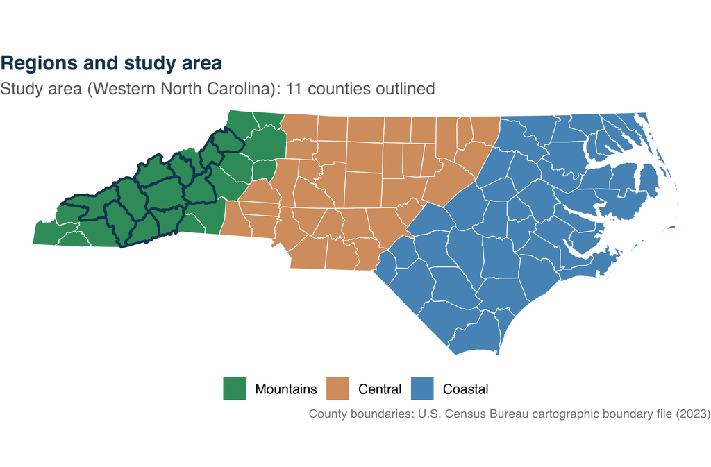

NC counties colored by the project’s three-region scheme; the study counties are outlined.

⬇ Download figure (PNG)

NC counties colored by the project’s three-region scheme; the study counties are outlined.

```r
if (!is.null(counties)) {
  g <- ggplot(counties) +
    geom_sf(aes(fill = factor(region, region_levels, region_labels)), color = "white", linewidth = 0.25) +
    geom_sf(data = study_counties_sf, fill = NA, color = fw_colors$navy, linewidth = 0.8) +
    scale_fill_manual(values = region_colors, name = NULL) +
    labs(title = "Regions and study area",
         subtitle = sprintf("Study area (%s): %d counties outlined", p$study_area, nrow(study_counties_sf)),
         caption = "County boundaries: U.S. Census Bureau cartographic boundary file (2023)") +
    map_theme
  show_fig(g, "01_region_map", 11, 5)
}
```

### Coverage and data quality

```r
event_level |>
  dplyr::group_by(year, is_partial_year) |>
  dplyr::summarise(
    events = dplyr::n(),
    county_records = sum(cz_type == "C"),
    zone_records = sum(cz_type == "Z"),
    with_coordinates = sum(!is.na(longitude)),
    flood_related = sum(is_flood_event),
    study_area = sum(in_study_area),
    deaths = sum(total_deaths),
    damage = sum(total_damage)
  ) |>
  dplyr::mutate(damage = dollars_short(damage)) |>
  dt(name = "noaa_coverage_by_year", page_length = 12)
```

| year | is_partial_year | events | county_records | zone_records | with_coordinates | flood_related | study_area | deaths | damage |
| --- | --- | --- | --- | --- | --- | --- | --- | --- | --- |
| 2016 | False | 1656 | 1220 | 436 | 1218 | 270 | 155 | 47 | $1.0B |
| 2017 | False | 1224 | 894 | 330 | 894 | 146 | 165 | 17 | $60.7M |
| 2018 | False | 1846 | 1186 | 660 | 1186 | 416 | 215 | 50 | $2.5B |
| 2019 | False | 1447 | 1173 | 274 | 1173 | 152 | 154 | 16 | $154.0M |
| 2020 | False | 1691 | 1292 | 399 | 1292 | 583 | 170 | 27 | $79.9M |
| 2021 | False | 904 | 636 | 268 | 636 | 135 | 113 | 13 | $221.1M |
| 2022 | False | 1586 | 1131 | 455 | 1131 | 106 | 135 | 10 | $31.0M |
| 2023 | False | 1380 | 1248 | 132 | 1248 | 195 | 112 | 4 | $308.2M |
| 2024 | False | 1570 | 1315 | 255 | 1315 | 468 | 200 | 98 | $2.1B |
| 2025 | False | 1679 | 1128 | 551 | 1128 | 239 | 161 | 13 | $47.0M |

[output cut: 1 more lines]

**WarningPartial year**

2026 is flagged `is_partial_year`: the latest event in the file is dated June 30, 2026, so its totals are incomplete and should not be compared with full years.

## 2.3 What the storm records show

### Storm activity over time

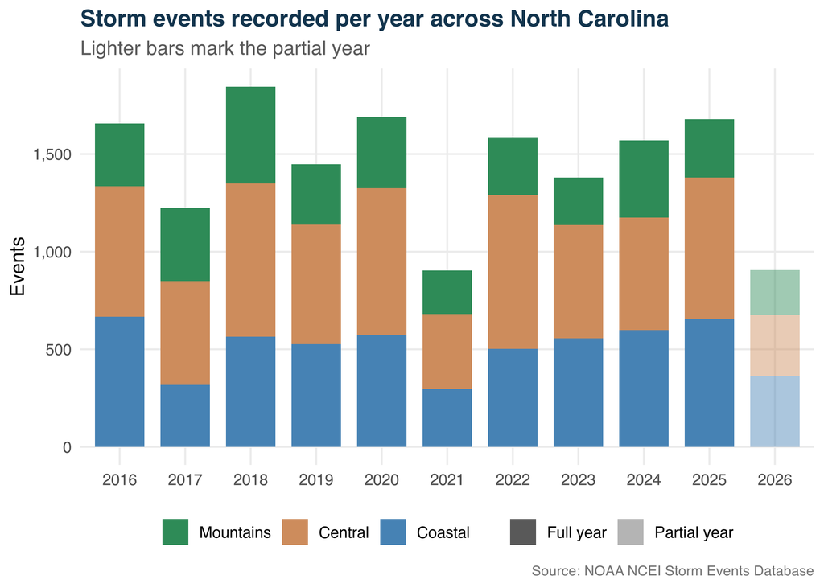

⬇ Download figure (PNG)

```r
g <- event_level |>
  dplyr::filter(!is.na(region)) |>
  dplyr::count(year, region, is_partial_year) |>
  dplyr::mutate(region = factor(region, region_levels, region_labels)) |>
  ggplot(aes(factor(year), n, fill = region, alpha = is_partial_year)) +
  geom_col(width = 0.75) +
  scale_fill_manual(values = region_colors) +
  scale_alpha_manual(values = c(`FALSE` = 1, `TRUE` = 0.45), labels = c("Full year", "Partial year")) +
  scale_y_continuous(labels = comma) +
  labs(title = "Storm events recorded per year across North Carolina",
       subtitle = "Lighter bars mark the partial year", x = NULL, y = "Events",
       fill = NULL, alpha = NULL, caption = noaa_caption)
show_fig(g, "02_events_by_year_region", 10, 5)
```

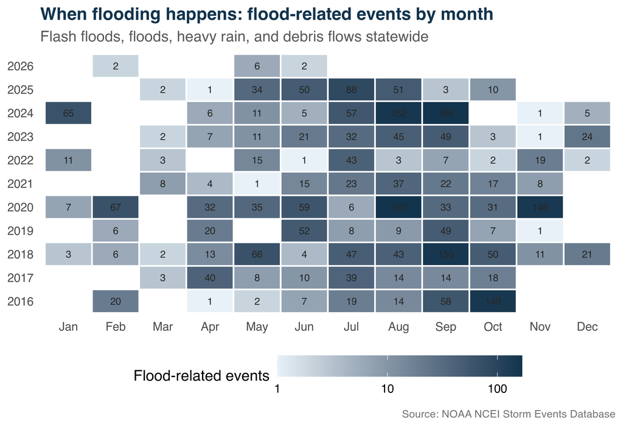

⬇ Download figure (PNG)

```r
flood_calendar <- event_level |>
  dplyr::filter(is_flood_event == 1) |>
  dplyr::count(event_year, event_month)
g <- ggplot(flood_calendar, aes(factor(event_month), factor(event_year), fill = n)) +
  geom_tile(color = "white", linewidth = 0.6) +
  geom_text(aes(label = n), size = 2.8, color = "gray15") +
  scale_fill_gradient(low = "#e8f1f7", high = fw_colors$navy, trans = "log10", name = "Flood-related events") +
  scale_x_discrete(labels = month.abb) +
  labs(title = "When flooding happens: flood-related events by month",
       subtitle = "Flash floods, floods, heavy rain, and debris flows statewide", x = NULL, y = NULL, caption = noaa_caption) +
  theme(panel.grid = element_blank(), legend.key.width = unit(1.4, "cm"))
show_fig(g, "03_flood_calendar", 10, 5)
```

### Which storms cause harm

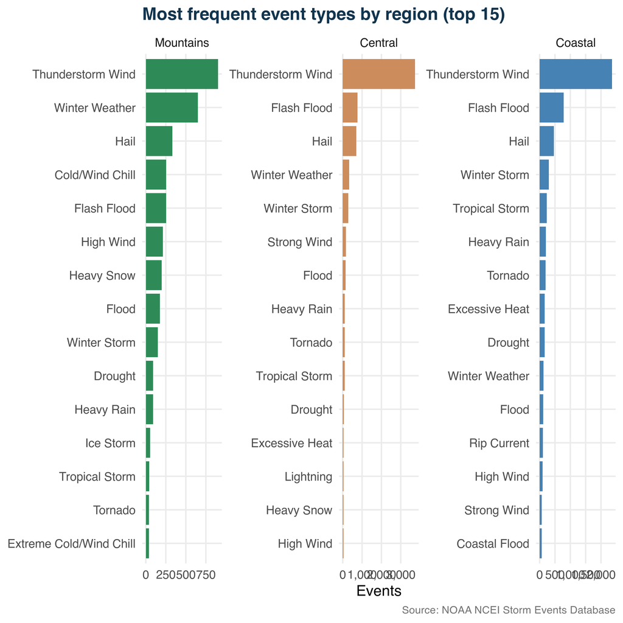

⬇ Download figure (PNG)

```r
top_types <- event_level |>
  dplyr::filter(!is.na(region)) |>
  dplyr::count(region, event_type) |>
  dplyr::group_by(region) |>
  dplyr::slice_max(n, n = p$top_n_event_types, with_ties = FALSE) |>
  dplyr::ungroup() |>
  dplyr::mutate(region = factor(region, region_levels, region_labels),
                event_key = paste(event_type, region, sep = "___"))
g <- ggplot(top_types, aes(n, reorder(event_key, n), fill = region)) +
  geom_col(show.legend = FALSE) +
  facet_wrap(~region, scales = "free", ncol = 3) +
  scale_y_discrete(labels = \(x) sub("___.*$", "", x)) +
  scale_x_continuous(labels = comma) +
  scale_fill_manual(values = region_colors) +
  labs(title = sprintf("Most frequent event types by region (top %d)", p$top_n_event_types),
       x = "Events", y = NULL, caption = noaa_caption)
show_fig(g, "04_top_event_types_by_region", 13, 7)
```

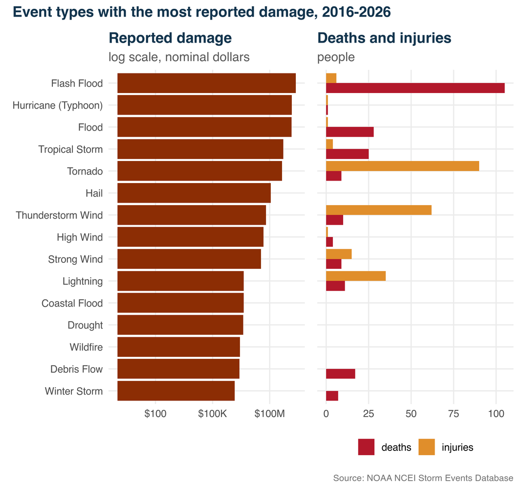

⬇ Download figure (PNG)

```r
impact_by_type <- event_level |>
  dplyr::group_by(event_type) |>
  dplyr::summarise(events = dplyr::n(), deaths = sum(total_deaths), injuries = sum(total_injuries),
                   damage = sum(total_damage))
top_damage_types <- dplyr::slice_max(impact_by_type, damage, n = p$top_n_event_types, with_ties = FALSE)

g1 <- ggplot(top_damage_types, aes(damage, reorder(event_type, damage))) +
  geom_col(fill = "#8C2D04") +
  scale_x_log10(labels = scales::label_dollar(scale_cut = scales::cut_short_scale())) +
  labs(title = "Reported damage", subtitle = "log scale, nominal dollars", x = NULL, y = NULL)
g2 <- top_damage_types |>
  tidyr::pivot_longer(c(deaths, injuries), names_to = "outcome", values_to = "people") |>
  ggplot(aes(people, reorder(event_type, damage), fill = outcome)) +
  geom_col(position = "dodge") +
  scale_fill_manual(values = c(deaths = fw_colors$alert, injuries = fw_colors$amber), name = NULL) +
  labs(title = "Deaths and injuries", subtitle = "people", x = NULL, y = NULL) +
  theme(axis.text.y = element_blank())
g <- (g1 | g2) + plot_annotation(
  title = sprintf("Event types with the most reported damage, %s-%s", p$start_year, p$end_year),
  caption = noaa_caption,
  theme = theme(plot.title = element_text(face = "bold", color = fw_colors$navy, size = 14)))
show_fig(g, "05_impacts_by_event_type", 13, 6.5)
```

```r
impact_by_type |>
  dplyr::arrange(dplyr::desc(damage)) |>
  dplyr::mutate(damage = dollars_short(damage)) |>
  dt(name = "impacts_by_event_type", page_length = 10)
```

| event_type | events | deaths | injuries | damage |
| --- | --- | --- | --- | --- |
| Flash Flood | 1800 | 105 | 6 | $2.4B |
| Hurricane (Typhoon) | 23 | 1 | 1 | $1.5B |
| Flood | 438 | 28 | 1 | $1.4B |
| Tropical Storm | 371 | 25 | 4 | $518.5M |
| Tornado | 339 | 9 | 90 | $445.1M |
| Hail | 1488 | 0 | 0 | $112.9M |
| Thunderstorm Wind | 7002 | 10 | 62 | $63.7M |
| High Wind | 342 | 4 | 1 | $47.4M |
| Strong Wind | 255 | 9 | 15 | $35.0M |
| Lightning | 112 | 11 | 35 | $4.4M |

[output cut: 21 more lines]

### Western North Carolina: one week dominates

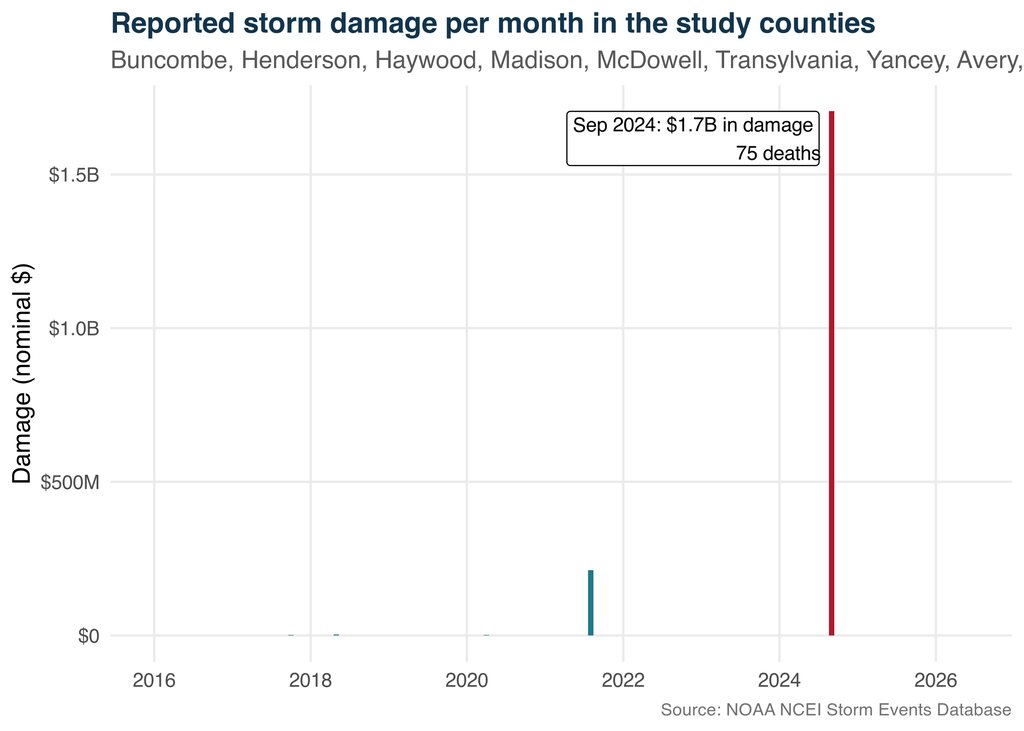

⬇ Download figure (PNG)

```r
study_monthly <- study |>
  dplyr::mutate(month = lubridate::floor_date(event_date, "month")) |>
  dplyr::group_by(month) |>
  dplyr::summarise(damage = sum(total_damage), deaths = sum(total_deaths))
peak <- dplyr::slice_max(study_monthly, damage, n = 1)
g <- ggplot(study_monthly, aes(month, damage)) +
  geom_col(fill = fw_colors$teal, width = 25) +
  geom_col(data = peak, fill = fw_colors$alert, width = 25) +
  annotate("label", x = peak$month, y = peak$damage, hjust = 1.05, vjust = 1, size = 3.4, label.size = 0,
           label = sprintf("%s: %s in damage\n%s deaths", format(peak$month, "%b %Y"), dollars_short(peak$damage), peak$deaths)) +
  scale_y_continuous(labels = scales::label_dollar(scale_cut = scales::cut_short_scale())) +
  labs(title = "Reported storm damage per month in the study counties",
       subtitle = paste(p$study_counties, collapse = ", "), x = NULL, y = "Damage (nominal $)", caption = noaa_caption)
show_fig(g, "06_study_area_damage_timeline", 11, 5)
```

The study-area events with the most damage are listed below. The narrative column is NOAA’s own text, truncated to 300 characters.

```r
study |>
  dplyr::slice_max(total_damage, n = p$top_n_events_table, with_ties = FALSE) |>
  dplyr::transmute(date = event_date, event_type, zone_or_county = cz_name,
                   damage = dollars_short(total_damage), deaths = total_deaths, injuries = total_injuries,
                   noaa_narrative = stringr::str_trunc(dplyr::coalesce(event_narrative, episode_narrative), 300)) |>
  dt(name = "study_area_top_events", page_length = 5)
```

| date | event_type | zone_or_county | damage | deaths | injuries | noaa_narrative |
| --- | --- | --- | --- | --- | --- | --- |
| 2024-09-27 | Flash Flood | BUNCOMBE | $300.0M | 9 | 0 | Rainfall rates began to intensify as tropical rainbands near the center of Helene swept across the area during the morning hours after 10-17 inches of rain fell across much of the county, with amounts… |
| 2024-09-27 | Flash Flood | BUNCOMBE | $300.0M | 15 | 0 | Historic and catastrophic flash flooding developed along the Swannanoa River basin during the early morning hours as rainfall rates began to intensify as tropical rainbands near the center of Helene s… |
| 2024-09-27 | Flash Flood | WATAUGA | $250.0M | 2 | 4 | Runoff from continued heavy rain resulted in numerous roads becoming flooded and impassible across Watauga County per reports from the public and from the Watauga County 911 Dispatch Center. Rainfall … |
| 2021-08-17 | Flash Flood | HAYWOOD | $200.0M | 5 | 0 | Emergency management and stream gauges reported catastrophic flash flooding developed within the Pigeon River watershed after 6 to 8 inches of rain fell in just a few hours across the northern slopes … |
| 2024-09-26 | Flash Flood | HENDERSON | $200.0M | 7 | 0 | Historic and catastrophic flash flooding developed along multiple streams across Henderson County during the overnight and early morning hours as rainfall rates began to intensify again during the eve… |
| 2024-09-27 | Flash Flood | HAYWOOD | $200.0M | 4 | 0 | Emergency management and stream gauges reported catastrophic flash flooding developed within the Pigeon River watershed for the second time in just over three years after 9 to 15 inches fell across th… |
| 2024-09-26 | Flash Flood | MCDOWELL | $100.0M | 1 | 0 | Stream gauges and emergency management reported catastrophic flash flooding developed along the Catawba River basin after 15-22 inches of rain fell across the western half of the county over three day… |
| 2024-09-26 | Flash Flood | YANCEY | $75.0M | 9 | 0 | Historic, catastrophic flash flooding developed along the Cane River and South Toe River basins during the overnight and early morning hours of the 27th as rainfall rates began to intensify again duri… |
| 2024-09-26 | Flash Flood | TRANSYLVANIA | $50.0M | 0 | 0 | Stream gauges and county comms reported major flash flooding developed along the headwaters of the French Broad basin after 15-22 inches of rain fell across much of the county over three days. Flash f… |
| 2024-09-26 | Flash Flood | AVERY | $40.0M | 6 | 0 | A stream gauge on the North Toe River in Newland indicated devastating flash flooding developed along the stream in Newland and vicinity as rainfall rates intensified during the evening of the 26th. T… |

## 2.4 What NOAA can’t tell us, and why we added more data

NOAA tells us **what** happened, **when**, and **how bad** it was. It does not tell us **why** one creek crossing became deadly while a similar storm a few miles away did little harm. Three gaps stand out:

1. **Outcomes, not conditions.** The records describe the storm and its toll, not the ground it fell on: slope, how close homes and roads are to streams, whether water can soak in or runs off pavement.
2. **Rare, extreme harm.** Only 1.2% of events caused a death. A model needs place-based context to tell a routine storm from a deadly one.
3. **Location detail varies.** 27% of events (mostly forecast-zone records) have no coordinates, but 98% of flood-related events do. For those events we can measure the landscape around the exact point where the event was reported.

Each gap maps to a public dataset:

| Question NOAA can’t answer | Dataset we added | What it measures around each event |
| --- | --- | --- |
| Was the event near a stream or river? | **USGS NHD High Resolution** (+ WBD watersheds) | distance to nearest stream, stream counts and density, containing HUC12 |
| Was the ground steep or rugged? | **USGS 3DEP-derived elevation, slope, roughness** | elevation, slope, and roughness at the point and nearby |
| Were roads crossing water nearby? | **NCDOT bridges/structures and culverts** | distance to and count of nearby crossings |
| Was the land paved or natural? | **USGS Annual NLCD imperviousness** | % impervious surface at and around the point |
| Would the soil absorb water? | **USDA SSURGO** | statewide soil summary (not yet mappable to events) |

# 3 The Supporting Datasets

Each dataset below has a summary card (source, contents, purpose, caveats) and a basic visualization.

## 3.1 Streams and watersheds: USGS NHD High Resolution

| Source | USGS National Hydrography Dataset, High Resolution (1:24,000), North Carolina state extract; includes the Watershed Boundary Dataset (WBD) |
| --- | --- |
| Contents | Flowlines (streams, rivers, canals, artificial paths) split across 2 shapefiles; HUC2-HUC16 watershed polygons; flowline files dated 2023-12-27 |
| Why we use it | Flood harm concentrates where people, roads, and buildings sit close to moving water |
| How we use it | StreamRiver (FType 460) and ArtificialPath (558) flowlines: distance to the nearest line, counts within 250m and 1km, and line density; the HUC12 subwatershed containing each event |
| Caveats | Point and buffer measures only. No upstream contributing area, flow accumulation, or HAND is computed |

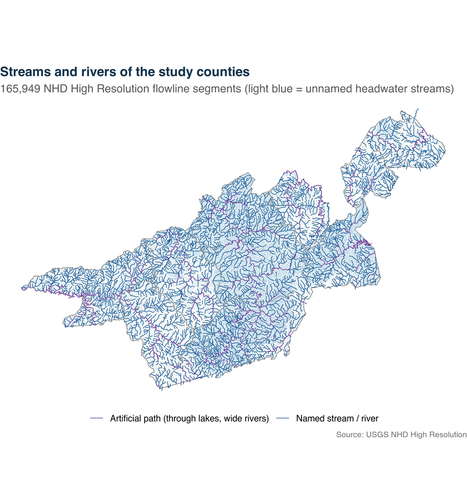

⬇ Download figure (PNG)

```r
if (!is.null(study_flowlines)) {
  fl_plot <- study_flowlines |>
    dplyr::mutate(kind = dplyr::case_when(ftype == 460 & !is.na(gnis_name) ~ "Named stream / river",
                                          ftype == 460 ~ "Unnamed stream",
                                          TRUE ~ "Artificial path (through lakes, wide rivers)"))
  g <- ggplot() +
    geom_sf(data = study_counties_sf, fill = "#fbfaf6", color = "gray55", linewidth = 0.35) +
    geom_sf(data = dplyr::filter(fl_plot, kind == "Unnamed stream"), color = "#a9cfe6", linewidth = 0.12) +
    geom_sf(data = dplyr::filter(fl_plot, kind != "Unnamed stream"), aes(color = kind), linewidth = 0.3) +
    scale_color_manual(values = c("Named stream / river" = "#1f5f99", "Artificial path (through lakes, wide rivers)" = "#6a3d9a"), name = NULL) +
    labs(title = "Streams and rivers of the study counties",
         subtitle = sprintf("%s NHD High Resolution flowline segments (light blue = unnamed headwater streams)", comma(nrow(fl_plot))),
         caption = "Source: USGS NHD High Resolution") +
    map_theme
  show_fig(g, "07_nhd_study_area_streams", 11, 8)
}
```

```r
if (length(flow_paths) > 0) {
  ftype_names <- c(`334` = "Connector", `336` = "Canal/Ditch", `420` = "Underground conduit", `428` = "Pipeline",
                   `460` = "Stream/River", `558` = "Artificial path", `566` = "Coastline")
  ftype_counts <- purrr::map(flow_paths, \(f) foreign::read.dbf(sub("\\.shp$", ".dbf", f), as.is = TRUE)["ftype"]) |>
    dplyr::bind_rows() |>
    dplyr::count(ftype, name = "segments_statewide") |>
    dplyr::mutate(description = unname(ftype_names[as.character(ftype)]),
                  used_in_features = ftype %in% unlist(p$nhd_flowline_ftypes)) |>
    dplyr::arrange(dplyr::desc(segments_statewide))
  dt(ftype_counts, name = "nhd_flowline_types", page_length = 8)
}
```

| ftype | segments_statewide | description | used_in_features |
| --- | --- | --- | --- |
| 460 | 622843 | Stream/River | True |
| 558 | 188040 | Artificial path | True |
| 336 | 59729 | Canal/Ditch | False |
| 566 | 5547 | Coastline | False |
| 334 | 3932 | Connector | False |
| 428 | 98 | Pipeline | False |
| 420 | 2 | Underground conduit | False |

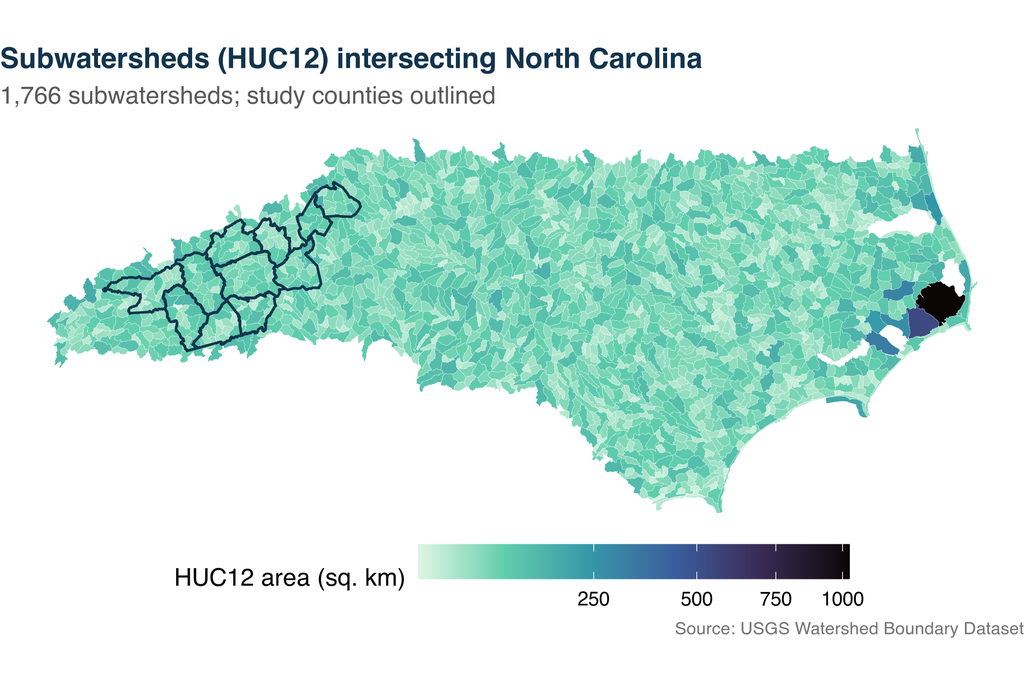

⬇ Download figure (PNG)

```r
huc_paths <- locate_nhd_layer("WBDHU12", paths$nhd_dir, paths$nhd_zip)
if (length(huc_paths) > 0 && !is.null(nc_boundary)) {
  huc12 <- sf::st_read(huc_paths[[1]], quiet = TRUE) |> clean_spatial_layer(p$analysis_crs) |>
    sf::st_filter(nc_boundary)
  g <- ggplot() +
    geom_sf(data = huc12, aes(fill = areasqkm), color = "white", linewidth = 0.05) +
    geom_sf(data = study_counties_sf, fill = NA, color = fw_colors$navy, linewidth = 0.6) +
    scale_fill_viridis_c(option = "G", direction = -1, name = "HUC12 area (sq. km)", trans = "sqrt") +
    labs(title = "Subwatersheds (HUC12) intersecting North Carolina",
         subtitle = sprintf("%s subwatersheds; study counties outlined", comma(nrow(huc12))),
         caption = "Source: USGS Watershed Boundary Dataset") +
    map_theme + theme(legend.key.width = unit(1.5, "cm"))
  show_fig(g, "08_wbd_huc12", 11, 5)
}
```

## 3.2 Terrain: USGS 3DEP-derived elevation, slope, and roughness

| Source | Elevation tiles from the AWS Terrain Tiles service via the `elevatr` R package (U.S. coverage sourced from USGS 3DEP), zoom 10 |
| --- | --- |
| Contents | Elevation (m), slope (degrees), and terrain roughness (m), clipped to North Carolina and projected to EPSG:32119 at 62.2 m cells |
| Why we use it | Steep, rugged terrain speeds runoff, feeds flash floods and debris flows, and isolates communities |
| How we use it | Value at the event point and mean within 250m |
| Caveats | 62.2 m cells are coarser than native 1/3 arc-second 3DEP; aspect is not used; no HAND or flow accumulation |

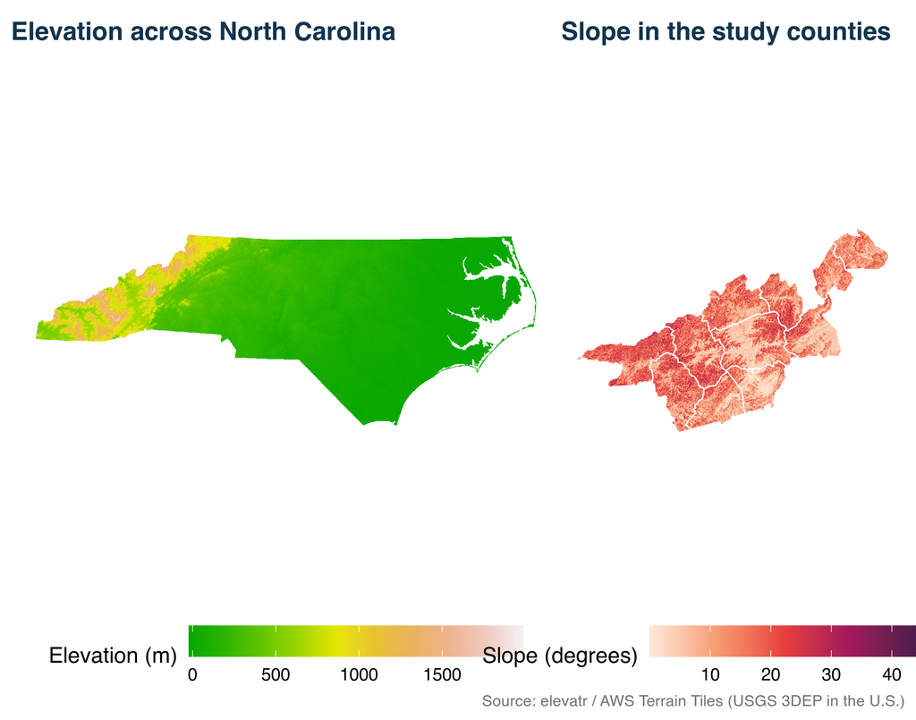

⬇ Download figure (PNG)

```r
raster_df <- function(path, fact, crop_to = NULL) {
  r <- terra::rast(path)[[1]]
  if (!is.null(crop_to)) r <- terra::crop(r, terra::project(terra::vect(crop_to), terra::crs(r)), mask = TRUE)
  if (fact > 1) r <- terra::aggregate(r, fact = fact, fun = "mean", na.rm = TRUE)
  df <- as.data.frame(r, xy = TRUE, na.rm = TRUE)
  names(df)[3] <- "value"
  list(df = df, crs = terra::crs(r))
}
if (file.exists(paths$dem) && file.exists(paths$slope)) {
  elev <- raster_df(paths$dem, fact = 8, crop_to = nc_boundary)
  g1 <- ggplot(elev$df, aes(x, y, fill = value)) + geom_raster() +
    scale_fill_gradientn(colors = terrain.colors(10), name = "Elevation (m)") +
    coord_sf(crs = elev$crs, datum = NA) +
    labs(title = "Elevation across North Carolina") + map_theme + theme(legend.key.width = unit(1.3, "cm"))
  slope <- raster_df(paths$slope, fact = 2, crop_to = study_counties_sf)
  g2 <- ggplot(slope$df, aes(x, y, fill = value)) + geom_raster() +
    geom_sf(data = study_counties_sf, inherit.aes = FALSE, fill = NA, color = "white", linewidth = 0.3) +
    scale_fill_viridis_c(option = "rocket", direction = -1, name = "Slope (degrees)") +
    coord_sf(crs = slope$crs, datum = NA) +
    labs(title = "Slope in the study counties") + map_theme + theme(legend.key.width = unit(1.3, "cm"))
  g <- (g1 | g2) + plot_layout(widths = c(1.6, 1)) +
    plot_annotation(caption = "Source: elevatr / AWS Terrain Tiles (USGS 3DEP in the U.S.)")
  show_fig(g, "09_terrain", 13, 5.5)
}
```

## 3.3 Road crossings: NCDOT bridges, structures, and culverts

| Source | NCDOT_Structures ArcGIS REST service (North Carolina Department of Transportation) |
| --- | --- |
| Contents | 14,318 structures (bridges) and 3,062 culverts as points; retrieved 2026-09-26 |
| Why we use it | Where roads cross streams, floodwater damages infrastructure, strands people, and blocks emergency access |
| How we use it | Distance to the nearest structure and culvert, and counts within 250m and 1km |
| Caveats | The inventory may be incomplete (e.g., non-state-maintained crossings); absence of an asset in the layer does not prove none exists |

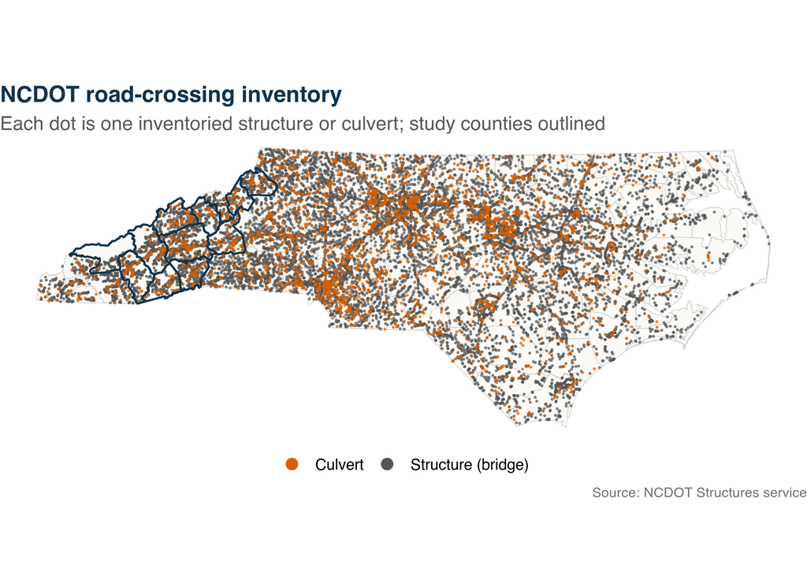

⬇ Download figure (PNG)

```r
if (nrow(ncdot) > 0 && !is.null(counties)) {
  g <- ggplot() +
    geom_sf(data = counties, fill = "#fbfaf6", color = "gray80", linewidth = 0.2) +
    geom_sf(data = ncdot, aes(color = asset), size = 0.25, alpha = 0.6) +
    geom_sf(data = study_counties_sf, fill = NA, color = fw_colors$navy, linewidth = 0.6) +
    scale_color_manual(values = c("Structure (bridge)" = "#555555", "Culvert" = "#d95f02"), name = NULL) +
    guides(color = guide_legend(override.aes = list(size = 3, alpha = 1))) +
    labs(title = "NCDOT road-crossing inventory",
         subtitle = "Each dot is one inventoried structure or culvert; study counties outlined",
         caption = "Source: NCDOT Structures service") +
    map_theme
  show_fig(g, "10_ncdot_assets", 11, 5)
}
```

```r
if (nrow(ncdot) > 0 && !is.null(counties)) {
  sf::st_join(ncdot, counties[c("NAME", "in_study", "ALAND")], join = sf::st_within) |>
    sf::st_drop_geometry() |>
    dplyr::filter(in_study) |>
    dplyr::count(county = NAME, asset, ALAND) |>
    tidyr::pivot_wider(names_from = asset, values_from = n, values_fill = 0) |>
    dplyr::mutate(assets_per_100_km2 = round((`Structure (bridge)` + Culvert) / (ALAND / 1e8), 1)) |>
    dplyr::select(-ALAND) |>
    dplyr::arrange(dplyr::desc(assets_per_100_km2)) |>
    dt(name = "ncdot_assets_study_counties", page_length = 11)
}
```

| county | Culvert | Structure (bridge) | assets_per_100_km2 |
| --- | --- | --- | --- |
| Buncombe | 84 | 471 | 32.6 |
| Henderson | 41 | 215 | 26.5 |
| Madison | 58 | 213 | 23.3 |
| Watauga | 33 | 148 | 22.4 |
| Haywood | 41 | 275 | 22 |
| Yancey | 28 | 147 | 21.6 |
| Jackson | 39 | 214 | 19.9 |
| McDowell | 45 | 163 | 18.3 |
| Avery | 21 | 87 | 16.9 |
| Transylvania | 27 | 131 | 16.1 |

[output cut: 1 more lines]

## 3.4 Paved surfaces: USGS Annual NLCD fractional imperviousness

| Source | USGS Annual National Land Cover Database (NLCD), Fractional Impervious Surface, via the USGS ImageServer |
| --- | --- |
| Contents | Percent impervious surface (0-100) for 2023, North Carolina extent, 39 m cells (EPSG:5070) |
| Why we use it | Pavement and rooftops shed water quickly, raising flood peaks in developed valleys |
| How we use it | Value at the event point and means within 250m and 1km |
| Caveats | A single **2023 static contemporary exposure layer**, not historical land cover for each event year; export cap made cells coarser than native 30 m |

[output not shown]

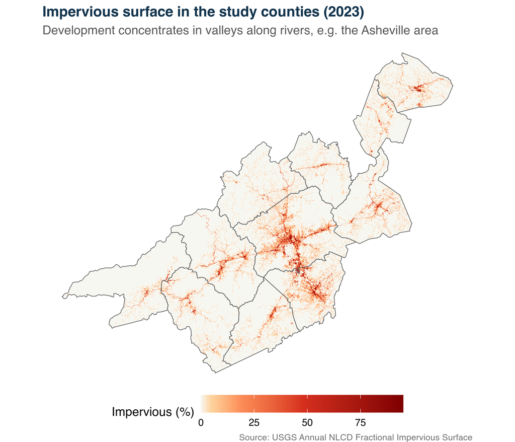

⬇ Download figure (PNG)

```r
if (file.exists(paths$nlcd) && !is.null(study_counties_sf)) {
  imp <- raster_df(paths$nlcd, fact = 2, crop_to = study_counties_sf)
  imp$df$value[imp$df$value > 100] <- NA
  g <- ggplot(imp$df, aes(x, y, fill = value)) + geom_raster() +
    geom_sf(data = sf::st_transform(study_counties_sf, imp$crs), inherit.aes = FALSE, fill = NA, color = "gray40", linewidth = 0.3) +
    scale_fill_gradientn(colors = c("#f7f7f2", "#fdd49e", "#fc8d59", "#d7301f", "#7f0000"),
                         values = c(0, 0.05, 0.2, 0.5, 1), name = "Impervious (%)", na.value = NA) +
    coord_sf(crs = imp$crs, datum = NA) +
    labs(title = sprintf("Impervious surface in the study counties (%s)", p$nlcd_vintage),
         subtitle = "Development concentrates in valleys along rivers, e.g. the Asheville area",
         caption = "Source: USGS Annual NLCD Fractional Impervious Surface") +
    map_theme + theme(legend.key.width = unit(1.4, "cm"))
  show_fig(g, "11_nlcd_impervious_study_area", 11, 6.5)
}
```

## 3.5 Soils: USDA SSURGO

| Source | USDA NRCS Soil Survey Geographic Database (SSURGO) via Soil Data Access (`soilDB`) |
| --- | --- |
| Contents | Tabular map-unit components (hydrologic soil group, drainage class, share of map unit) and horizons (saturated conductivity, water capacity) for NC survey areas |
| Why we use it | Soils that absorb water slowly (hydrologic groups C and D) produce more runoff |
| How we use it | Summary only. The files have no map-unit geometry, so soil values are **not** assigned to events (doing so would invent values) |
| Caveats | Event-level soil features need gSSURGO/SSURGO polygons joined by `mukey` (parameter `soil_spatial_path`) |

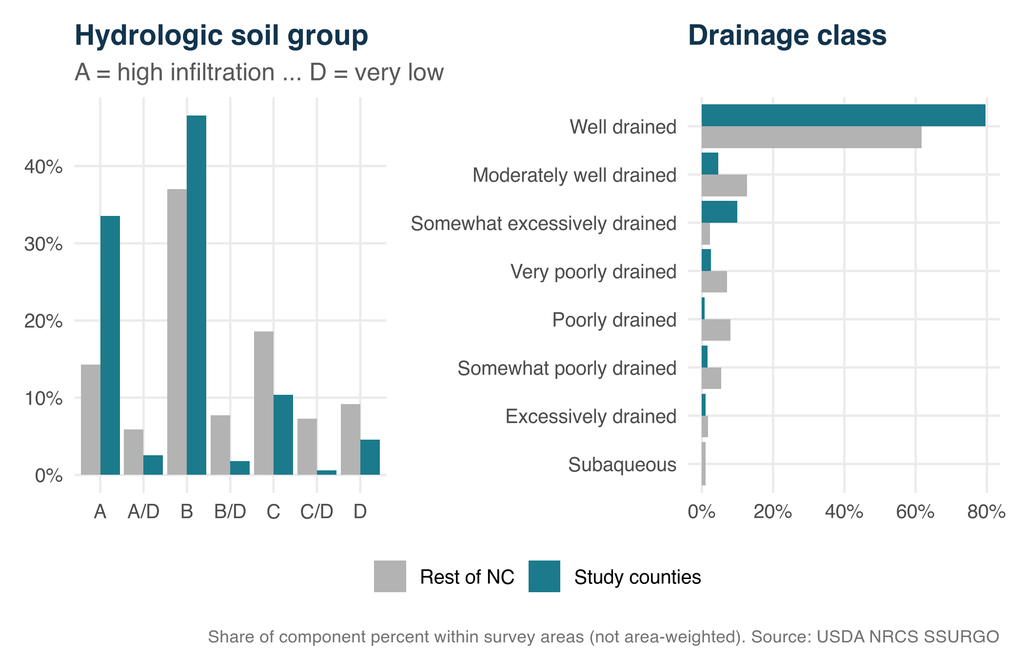

⬇ Download figure (PNG)

```r
if (file.exists(soil_file)) {
  soils <- readr::read_csv(soil_file, show_col_types = FALSE) |>
    dplyr::mutate(county = toupper(stringr::str_remove(areaname, " County, North Carolina$")),
                  area = dplyr::if_else(county %in% toupper(p$study_counties), "Study counties", "Rest of NC"),
                  comppct_r = as.numeric(comppct_r))
  share <- function(var) {
    soils |>
      dplyr::filter(!is.na(.data[[var]])) |>
      dplyr::group_by(area, value = .data[[var]]) |>
      dplyr::summarise(weight = sum(comppct_r, na.rm = TRUE)) |>
      dplyr::mutate(share = weight / sum(weight)) |>
      dplyr::ungroup()
  }
  area_fill <- scale_fill_manual(values = c("Study counties" = fw_colors$teal, "Rest of NC" = "gray70"), name = NULL)
  g1 <- ggplot(share("hydgrp"), aes(value, share, fill = area)) + geom_col(position = "dodge") +
    scale_y_continuous(labels = scales::percent) + area_fill +
    labs(title = "Hydrologic soil group", subtitle = "A = high infiltration ... D = very low", x = NULL, y = NULL)
  g2 <- share("drainagecl") |>
    ggplot(aes(share, reorder(value, share), fill = area)) + geom_col(position = "dodge") +
    scale_x_continuous(labels = scales::percent) + area_fill +
    labs(title = "Drainage class", x = NULL, y = NULL)
  g <- (g1 | g2) + plot_layout(guides = "collect") &
    theme(legend.position = "bottom")
  g <- g + plot_annotation(caption = "Share of component percent within survey areas (not area-weighted). Source: USDA NRCS SSURGO")
  show_fig(g, "12_ssurgo_summary", 12, 4.8)
}
```

## 3.6 Datasets not yet included

- **Rainfall** (e.g., event rainfall totals): not included yet. No other variable stands in for rainfall. Enable it with `include_rainfall_features` and `rainfall_path` (CSV keyed by `event_id`).
- **Community vulnerability**: not part of this spatial feature table, but county social vulnerability (SOVI) and population density from FEMA’s National Risk Index are added at the modeling stage (Section 7).

# 4 Bringing the Data Together

## 4.1 One coordinate system, clean geometry

The inputs arrive in four coordinate systems: WGS 84 (NOAA, NCDOT), NAD83 (NHD, WBD), NC State Plane (terrain), and CONUS Albers (NLCD). Every vector layer goes through the same three steps before any spatial operation:

1. `st_zm()` drops Z/M dimensions. NHD flowlines are stored as `3D Measured` (XYZM), which GEOS cannot process.
2. `st_make_valid()` repairs invalid geometries.
3. `st_transform()` projects to **EPSG:32119** (NAD83 / North Carolina, meters), where all distances and buffers are measured.

Rasters are **never resampled**. Instead, event points and buffers are projected into each raster’s own CRS for extraction, so the original cell values are preserved.

## 4.2 Features measured around every event

| Feature group | Source | Features | Method |
| --- | --- | --- | --- |
| Stream proximity | NHD HR | distance_to_stream_m, streams_within_250m, streams_within_1km, stream_density_km_per_km2_250m | Nearest-line distance; count of lines touching a circular buffer; clipped line length / buffer area |
| Watershed | WBD | huc12, huc12_area_km2 | Subwatershed polygon containing the point (membership only) |
| Road crossings | NCDOT | distance_to_nearest_culvert_m / structure_m, culverts_/structures_within_250m and _1km | Nearest-point distance; count within buffer |
| Terrain | 3DEP-derived | elevation_m, slope_degrees, terrain_roughness, *_mean_250m | Cell value at point; mean of cells in buffer |
| Imperviousness | Annual NLCD | impervious_mean_event, impervious_mean_250m, impervious_mean_1km | Cell value at point; mean of cells in buffer (0-100 %) |

```r
scope_filter <- switch(
  p$feature_event_scope,
  all               = rep(TRUE, nrow(event_level)),
  flood             = event_level$is_flood_event == 1,
  flood_or_tropical = event_level$is_flood_event == 1 | event_level$is_tropical_event == 1,
  stop("feature_event_scope must be one of: all, flood, flood_or_tropical")
)
events_in_scope <- event_level[scope_filter, ]

spatial_settings <- list(
  analysis_crs = p$analysis_crs, geographic_crs = p$geographic_crs,
  event_buffer_m = p$event_buffer_m, stream_buffer_m = p$stream_buffer_m,
  infrastructure_buffer_m = p$infrastructure_buffer_m,
  nhd_flowline_ftypes = unlist(p$nhd_flowline_ftypes), compute_stream_density = p$compute_stream_density,
  include_nhd_features = p$include_nhd_features, include_wbd_features = p$include_wbd_features,
  include_ncdot_features = p$include_ncdot_features, include_dem_features = p$include_dem_features,
  include_nlcd_features = p$include_nlcd_features, nlcd_vintage = p$nlcd_vintage
)

spatial <- cached_spatial_features(
  events_in_scope,
  inputs      = paths[c("nhd_zip", "nhd_dir", "ncdot_culverts", "ncdot_structures", "dem", "slope", "roughness", "nlcd")],
  settings    = spatial_settings,
  cache_dir   = paths$derived_dir,
  use_cache   = isTRUE(p$use_cached_features),
  refresh     = isTRUE(p$refresh_derived_data),
  project_dir = project_dir
)
feature_cols <- setdiff(names(spatial$features), "event_id")
```

**NoteSpatial features for 11,610 events (loaded from cache)**

- NHD HR flowlines (ftype 460/558) from 2 shapefile(s): nearest distance and counts within 250m/1km
- WBD HUC12 polygon containing the event point (membership only, not upstream area)
- NCDOT culverts/structures: nearest distance and counts within 250m/1km
- DEM-derived terrain (62.2 m cells): point value and mean within 250m
- Annual NLCD fractional imperviousness 2023 (39.0 m cells; 2023 static contemporary exposure layer): point value and means within 250m/1km

Computed 2026-09-27 09:20. The cache in `data/derived` is reused only when every setting and input file is unchanged; set `refresh_derived_data: true` to force a rebuild.

## 4.3 Input validation

```r
raster_row <- function(path, dataset) {
  if (is.na(path) || !file.exists(path)) return(tibble::tibble(dataset = dataset, file = basename(path), crs = NA, cell_size_m = NA, cells = NA))
  r <- terra::rast(path)
  tibble::tibble(dataset = dataset, file = basename(path), crs = paste0("EPSG:", terra::crs(r, describe = TRUE)$code),
                 cell_size_m = round(terra::res(r)[1], 1), cells = comma(terra::ncell(r)))
}
layer_table <- dplyr::bind_rows(
  spatial$layer_summary |> dplyr::transmute(dataset, file, crs, geometry_before_cleaning = geometry_type, features = comma(features)),
  dplyr::bind_rows(raster_row(paths$dem, "DEM"), raster_row(paths$slope, "Slope"), raster_row(paths$roughness, "Roughness"),
                   raster_row(paths$nlcd, paste("NLCD imperviousness", p$nlcd_vintage))) |>
    dplyr::transmute(dataset, file, crs, geometry_before_cleaning = paste0("raster, ", cell_size_m, " m cells"), features = cells)
)
dt(layer_table, name = "spatial_input_validation", page_length = 10)
```

| dataset | file | crs | geometry_before_cleaning | features |
| --- | --- | --- | --- | --- |
| NHD flowlines | NHDFlowline_0.shp | NAD83 | 3D Measured Line String | 550,000 |
| NHD flowlines | NHDFlowline_1.shp | NAD83 | 3D Measured Line String | 330,191 |
| WBD HUC12 | WBDHU12.shp | NAD83 | Polygon | 2,541 |
| NCDOT culverts | ncdot_culverts_nc.gpkg | WGS 84 | Point | 3,062 |
| NCDOT structures | ncdot_structures_nc.gpkg | WGS 84 | Point | 14,318 |
| DEM | 3dep_dem_north_carolina_epsg32119.tif | EPSG:32119 | raster, 62.2 m cells | 102,035,307 |
| Slope | slope_degrees_epsg32119.tif | EPSG:32119 | raster, 62.2 m cells | 102,035,307 |
| Roughness | roughness_epsg32119.tif | EPSG:32119 | raster, 62.2 m cells | 102,035,307 |
| NLCD imperviousness 2023 | annual_nlcd_fractional_impervious_2023_NC.tif | EPSG:5070 | raster, 39 m cells | 176,260,000 |

## 4.4 Assembling the event-level table

```r
event_level <- event_level |>
  dplyr::mutate(split = assign_split(event_year, p$train_end_year, p$validation_end_year))

targets <- add_targets(event_level,
                       damage_quantile      = p$damage_quantile,
                       positive_damage_only = p$target_positive_damage_only,
                       death_target_value   = p$death_target_value,
                       threshold_basis      = p$target_threshold_basis)
event_level <- targets$events

noaa_dates <- range(noaa_inventory$creation_date)
vintages <- list(
  noaa  = sprintf("NOAA Storm Events %s-%s (file revisions %s to %s)", p$start_year, p$end_year, noaa_dates[1], noaa_dates[2]),
  nhd   = if (!is.na(nhd_date)) sprintf("NHD HR state extract (flowlines dated %s)", nhd_date) else "NHD HR state extract",
  ncdot = if (!is.na(ncdot_date)) sprintf("NCDOT Structures service (retrieved %s)", ncdot_date) else "NCDOT Structures service",
  dem   = "elevatr AWS terrain tiles (3DEP in US)",
  nlcd  = paste("Annual NLCD", p$nlcd_vintage, "(static)")
)
row_vintage <- paste(c(vintages$noaa, if (p$include_nhd_features) vintages$nhd, if (p$include_ncdot_features) vintages$ncdot,
                       if (p$include_dem_features) vintages$dem, if (p$include_nlcd_features) vintages$nlcd), collapse = "; ")

model_table <- event_level |>
  dplyr::left_join(spatial$features, by = "event_id") |>
  dplyr::left_join(optional_features, by = "event_id") |>
  dplyr::mutate(
    has_features = event_id %in% spatial$features$event_id,
    spatial_feature_method = dplyr::if_else(has_features, "point_buffer (no catchment/upstream area)", "none"),
    source_vintage = row_vintage,
    data_coverage_warning = purrr::pmap_chr(
      list(has_features, event_coordinate_quality, is_partial_year, cz_type, event_id %in% events_in_scope$event_id),
      function(has, quality, partial, cz, in_scope) {
        flags <- c(if (!in_scope) "outside_feature_scope",
                   if (in_scope && !has) paste0("no_usable_coordinates(", quality, ")"),
                   if (partial) "partial_year",
                   if (cz == "Z") "forecast_zone_record",
                   if (has && p$include_ncdot_features) "ncdot_inventory_may_be_incomplete",
                   if (has && p$include_nlcd_features) paste0("nlcd_", p$nlcd_vintage, "_static_layer"))
        if (length(flags) == 0) "none" else paste(flags, collapse = "; ")
      })
  ) |>
  dplyr::select(-has_features)

roles <- column_roles(feature_cols, optional_feature_cols)
model_table <- dplyr::select(model_table, dplyr::any_of(c(roles$identifier, roles$context, roles$predictor, roles$outcome, roles$target)))

final_check <- duplication_check(model_table, "model table", "event_id")
stopifnot(final_check$max_rows_per_event == 1, final_check$duplicated_events == 0)
```

The combined table has **15,889 rows** (one per storm event) and **69 columns**. NOAA narratives are left out because they describe the outcomes.

## 4.5 Feature completeness and ranges

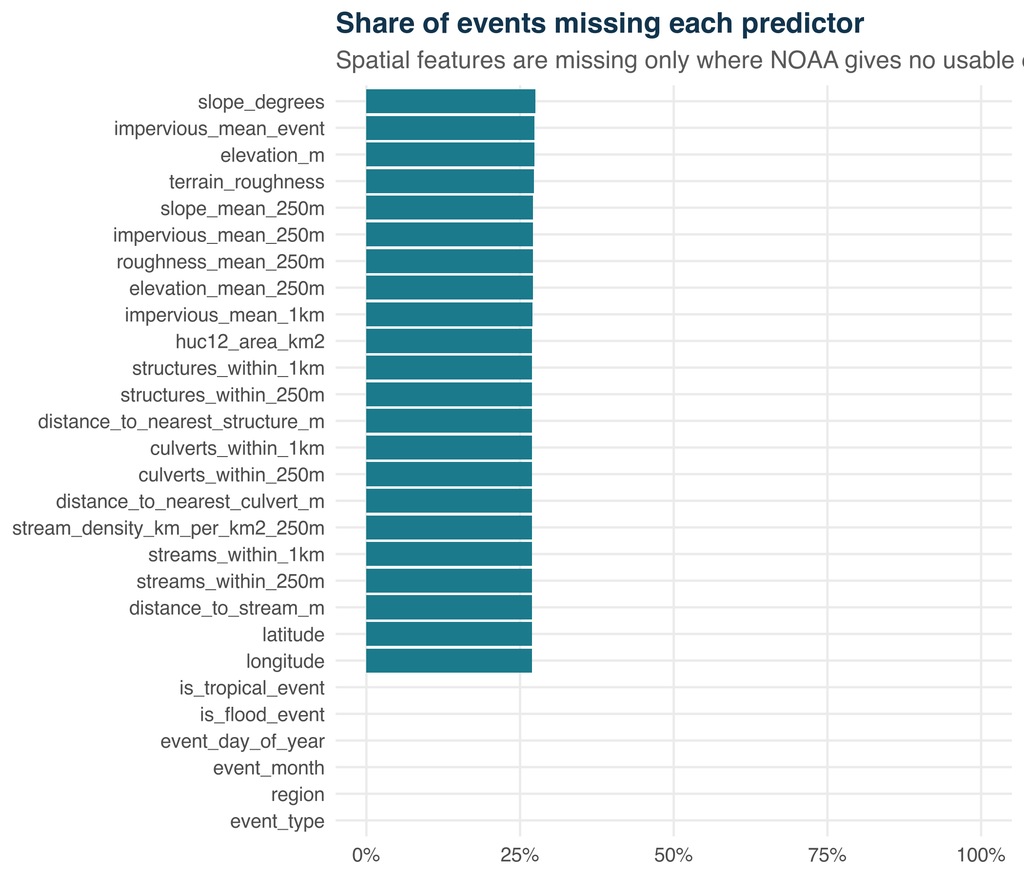

⬇ Download figure (PNG)

```r
missingness <- model_table |>
  dplyr::summarise(dplyr::across(dplyr::all_of(intersect(roles$predictor, names(model_table))), \(x) mean(is.na(x)))) |>
  tidyr::pivot_longer(dplyr::everything(), names_to = "feature", values_to = "missing") |>
  dplyr::arrange(missing)
g <- ggplot(missingness, aes(missing, forcats::fct_inorder(feature))) +
  geom_col(fill = fw_colors$teal) +
  scale_x_continuous(labels = scales::percent, limits = c(0, 1)) +
  labs(title = "Share of events missing each predictor",
       subtitle = "Spatial features are missing only where NOAA gives no usable coordinates; missing is never filled with zero",
       x = NULL, y = NULL)
show_fig(g, "13_predictor_missingness", 10, 6)
```

```r
model_table |>
  dplyr::filter(!is.na(longitude)) |>
  dplyr::select(dplyr::any_of(setdiff(feature_cols, c("huc12", "huc12_name")))) |>
  tidyr::pivot_longer(dplyr::everything(), names_to = "feature") |>
  dplyr::group_by(feature) |>
  dplyr::summarise(n = sum(!is.na(value)), min = min(value, na.rm = TRUE), median = median(value, na.rm = TRUE),
                   mean = mean(value, na.rm = TRUE), p90 = quantile(value, 0.9, na.rm = TRUE), max = max(value, na.rm = TRUE)) |>
  dplyr::mutate(dplyr::across(min:max, \(x) round(x, 2))) |>
  dt(name = "spatial_feature_summary", page_length = 25)
```

| feature | n | min | median | mean | p90 | max |
| --- | --- | --- | --- | --- | --- | --- |
| culverts_within_1km | 11610 | 0 | 0 | 0.21 | 1 | 9 |
| culverts_within_250m | 11610 | 0 | 0 | 0.02 | 0 | 3 |
| distance_to_nearest_culvert_m | 11610 | 6.52 | 2900.96 | 4571.25 | 8479.78 | 71257.56 |
| distance_to_nearest_structure_m | 11610 | 1.26 | 1310.06 | 1686.95 | 3331.29 | 24089.77 |
| distance_to_stream_m | 11610 | 0.09 | 210.15 | 274.27 | 531.56 | 7435.97 |
| elevation_m | 11551 | -1 | 140.39 | 199.24 | 405.64 | 1773.09 |
| elevation_mean_250m | 11581 | -1.13 | 139.13 | 198.65 | 404.48 | 1784.96 |
| huc12_area_km2 | 11609 | 21.97 | 89.16 | 90.37 | 130.17 | 330.51 |
| impervious_mean_1km | 11598 | 0 | 5.01 | 11.58 | 32.65 | 74.36 |
| impervious_mean_250m | 11581 | 0 | 6.3 | 14.11 | 39.79 | 87.57 |

[output cut: 10 more lines]

# 5 What the Combined Data Shows

The figures below are descriptive comparisons, not model results.

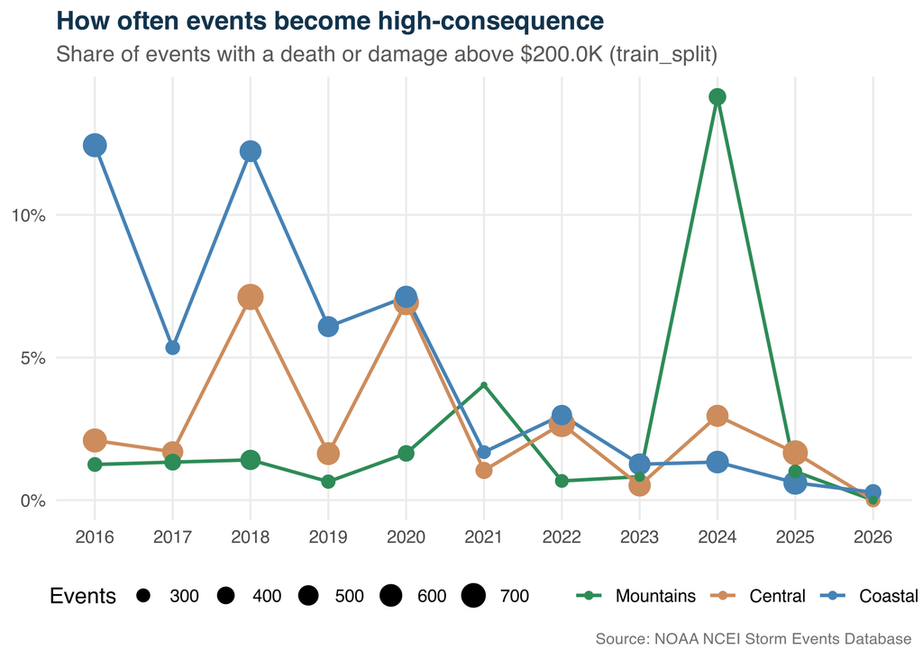

⬇ Download figure (PNG)

```r
balance <- model_table |>
  dplyr::filter(!is.na(region)) |>
  dplyr::group_by(event_year, region) |>
  dplyr::summarise(events = dplyr::n(), rate = mean(high_consequence)) |>
  dplyr::mutate(region = factor(region, region_levels, region_labels))
g <- ggplot(balance, aes(event_year, rate, color = region)) +
  geom_line(linewidth = 0.9) + geom_point(aes(size = events)) +
  scale_color_manual(values = region_colors, name = NULL) +
  scale_y_continuous(labels = scales::percent) + scale_x_continuous(breaks = years) +
  labs(title = "How often events become high-consequence",
       subtitle = sprintf("Share of events with a death or damage above %s (%s)", dollars_short(targets$threshold), p$target_threshold_basis),
       x = NULL, y = NULL, size = "Events", caption = noaa_caption)
show_fig(g, "14_high_consequence_rate", 10, 5)
```

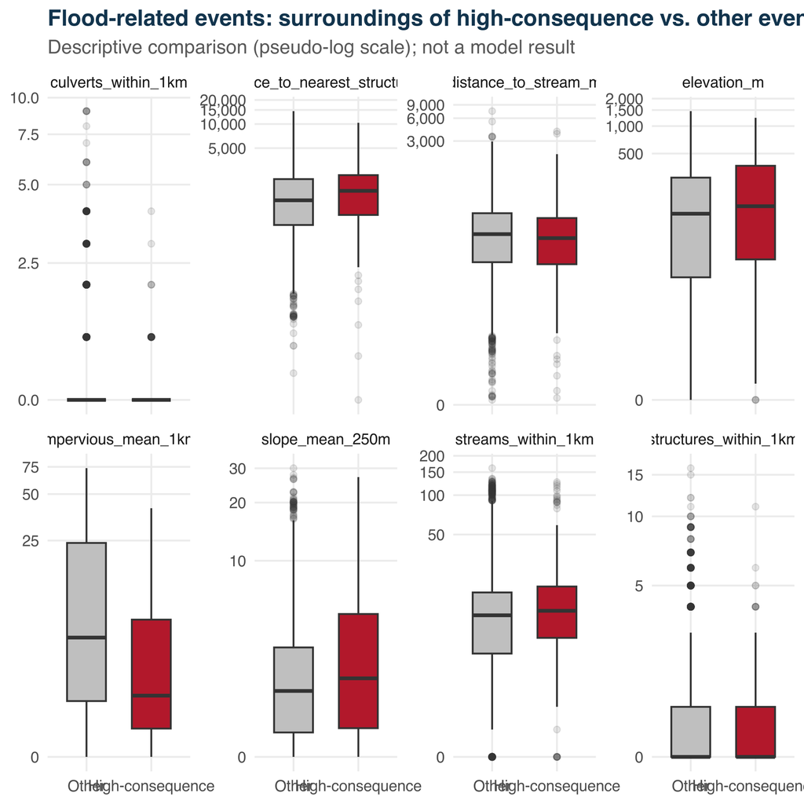

⬇ Download figure (PNG)

```r
compare_cols <- intersect(c("distance_to_stream_m", paste0("streams_within_", ib), paste0("slope_mean_", eb),
                            "elevation_m", paste0("impervious_mean_", ib), paste0("structures_within_", ib),
                            paste0("culverts_within_", ib), "distance_to_nearest_structure_m"), names(model_table))
plot_data <- model_table |>
  dplyr::filter(is_flood_event == 1, !is.na(longitude)) |>
  dplyr::select(high_consequence, dplyr::all_of(compare_cols)) |>
  tidyr::pivot_longer(-high_consequence, names_to = "feature") |>
  dplyr::filter(!is.na(value)) |>
  dplyr::mutate(label = factor(high_consequence, c(0, 1), c("Other", "High-consequence")))
if (nrow(plot_data) > 0) {
  g <- ggplot(plot_data, aes(label, value, fill = label)) +
    geom_boxplot(outlier.alpha = 0.12, show.legend = FALSE, width = 0.6) +
    facet_wrap(~feature, scales = "free_y", ncol = 4) +
    scale_y_continuous(trans = scales::pseudo_log_trans(base = 10), labels = comma) +
    scale_fill_manual(values = c("gray75", fw_colors$alert)) +
    labs(title = "Flood-related events: surroundings of high-consequence vs. other events",
         subtitle = "Descriptive comparison (pseudo-log scale); not a model result", x = NULL, y = NULL)
  show_fig(g, "15_features_by_target", 13, 7)
}
```

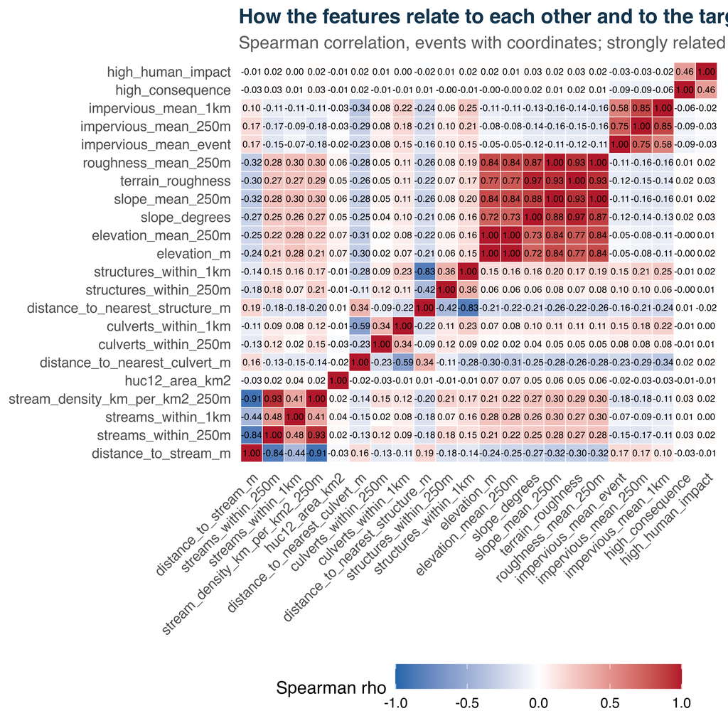

⬇ Download figure (PNG)

```r
num_features <- model_table |>
  dplyr::filter(!is.na(longitude)) |>
  dplyr::select(dplyr::any_of(setdiff(feature_cols, c("huc12", "huc12_name"))), high_consequence, high_human_impact) |>
  dplyr::select(dplyr::where(is.numeric))
cm <- stats::cor(num_features, use = "pairwise.complete.obs", method = "spearman")
cm_long <- as.data.frame(as.table(cm)) |> dplyr::rename(a = Var1, b = Var2, rho = Freq)
g <- ggplot(cm_long, aes(a, b, fill = rho)) +
  geom_tile(color = "white") +
  geom_text(aes(label = sprintf("%.2f", rho)), size = 2.2) +
  scale_fill_gradient2(low = "#2166ac", mid = "white", high = fw_colors$alert, limits = c(-1, 1), name = "Spearman rho") +
  labs(title = "How the features relate to each other and to the targets",
       subtitle = "Spearman correlation, events with coordinates; strongly related features carry overlapping information", x = NULL, y = NULL) +
  theme(axis.text.x = element_text(angle = 45, hjust = 1), panel.grid = element_blank(), legend.key.width = unit(1.4, "cm"))
show_fig(g, "16_feature_correlation", 12, 10)
```

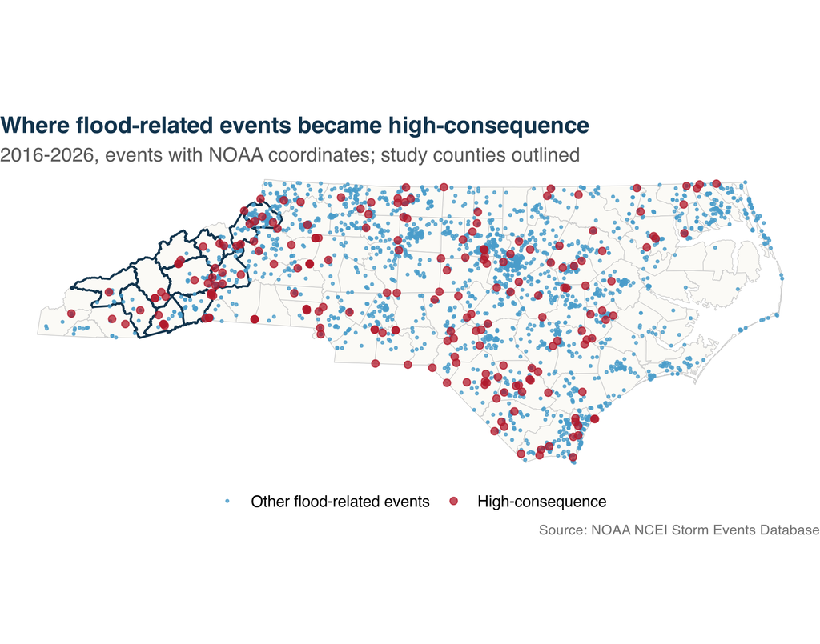

⬇ Download figure (PNG)

```r
if (isTRUE(p$create_static_maps) && !is.null(counties)) {
  flood_pts <- dplyr::filter(event_points, is_flood_event == 1) |> dplyr::arrange(high_consequence) |>
    dplyr::mutate(label = factor(high_consequence, c(0, 1), c("Other flood-related events", "High-consequence")))
  g <- ggplot() +
    geom_sf(data = counties, fill = "#fbfaf6", color = "gray80", linewidth = 0.2) +
    geom_sf(data = study_counties_sf, fill = NA, color = fw_colors$navy, linewidth = 0.6) +
    geom_sf(data = flood_pts, aes(color = label, size = label), alpha = 0.75) +
    scale_color_manual(values = c(fw_colors$river, fw_colors$alert), name = NULL) +
    scale_size_manual(values = c(0.5, 1.8), name = NULL) +
    labs(title = "Where flood-related events became high-consequence",
         subtitle = sprintf("%s-%s, events with NOAA coordinates; study counties outlined", p$start_year, p$end_year),
         caption = noaa_caption) +
    map_theme
  show_fig(g, "17_map_statewide_flood_events", 12, 5.8)
}
```

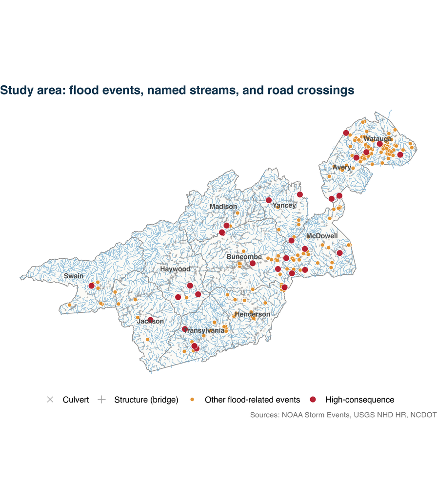

⬇ Download figure (PNG)

```r
if (isTRUE(p$create_static_maps) && !is.null(study_counties_sf)) {
  named <- if (!is.null(study_flowlines)) dplyr::filter(study_flowlines, ftype == 460, !is.na(gnis_name)) else NULL
  infra <- if (nrow(ncdot) > 0) sf::st_filter(ncdot, sf::st_union(study_counties_sf)) else NULL
  study_pts <- event_points |> dplyr::filter(is_flood_event == 1) |> sf::st_filter(sf::st_union(study_counties_sf)) |>
    dplyr::arrange(high_consequence) |>
    dplyr::mutate(label = factor(high_consequence, c(0, 1), c("Other flood-related events", "High-consequence")))
  g <- ggplot() +
    geom_sf(data = study_counties_sf, fill = "#fbfaf6", color = "gray55", linewidth = 0.35) +
    { if (!is.null(named)) geom_sf(data = named, color = "#7fb3d5", linewidth = 0.25) } +
    { if (!is.null(infra)) geom_sf(data = infra, aes(shape = asset), color = "gray60", size = 0.35, alpha = 0.5) } +
    geom_sf(data = study_pts, aes(fill = label, size = label), shape = 21, color = "white", stroke = 0.3, alpha = 0.95) +
    geom_sf_text(data = study_counties_sf, aes(label = NAME), size = 2.8, color = "gray30", fontface = "bold") +
    scale_fill_manual(values = c(fw_colors$amber, fw_colors$alert), name = NULL) +
    scale_size_manual(values = c(1.9, 3.2), name = NULL) +
    scale_shape_manual(values = c("Structure (bridge)" = 3, "Culvert" = 4), name = NULL) +
    guides(shape = guide_legend(override.aes = list(size = 2.5, alpha = 1))) +
    labs(title = "Study area: flood events, named streams, and road crossings",
         caption = "Sources: NOAA Storm Events, USGS NHD HR, NCDOT") +
    map_theme
  show_fig(g, "18_map_study_area", 11, 9)
}
```

### Explore the events interactively

Hover over a point for details; zoom and pan with the mouse. Map tiles need an internet connection.

```r
if (isTRUE(p$create_interactive_maps) && has_pkg("plotly")) {
  pts <- model_table |>
    dplyr::filter(!is.na(longitude), is_flood_event == 1) |>
    dplyr::mutate(status = ifelse(high_consequence == 1, "High-consequence", "Other flood-related"),
                  hover = sprintf("<b>%s</b><br>%s | %s<br>Damage: %s | Deaths: %s | Injuries: %s",
                                  event_type, event_date, cz_name, format_dollars(total_damage), total_deaths, total_injuries))
  plotly::plot_ly(pts, type = "scattermapbox", mode = "markers", lon = ~longitude, lat = ~latitude,
                  color = ~status, colors = c(fw_colors$alert, fw_colors$river),
                  marker = list(size = ~ifelse(high_consequence == 1, 9, 5), opacity = 0.8),
                  text = ~hover, hoverinfo = "text") |>
    plotly::layout(mapbox = list(style = "open-street-map", zoom = 5.6, center = list(lon = -79.6, lat = 35.4)),
                   legend = list(orientation = "h", y = -0.05), margin = list(l = 0, r = 0, t = 0, b = 0), height = 560)
}
```

[interactive chart not shown]

# 6 Machine-Learning-Ready Data

## 6.1 Outcome labels

```r
targets$definitions |>
  dplyr::transmute(target_name, definition,
                   damage_threshold = scales::dollar(damage_threshold_dollars),
                   positives, prevalence = scales::percent(prevalence, accuracy = 0.1), leakage_warning) |>
  knitr::kable()
```

| target_name | definition | damage_threshold | positives | prevalence | leakage_warning |
| --- | --- | --- | --- | --- | --- |
| high_consequence | 1 if total_deaths >= 1 OR total_damage > the 0.9 quantile of positive damage values (basis: train_split); 0 otherwise. | $200,000 | 576 | 3.6% | Threshold computed on training rows only. |
| high_human_impact | 1 if total_deaths >= 1 OR total_injuries >= 1; 0 otherwise. | NA | 272 | 1.7% | Outcome label; never use injuries or deaths as predictors. |

**ImportantLeakage rules for the modeling team**

- **Damage threshold:** computed from training years only ($200,000), so the target is leakage-safe as exported.
- **Never use outcome columns as predictors**: deaths, injuries, damage, `any_*`, fatality-record counts, or the damage-reported flags. The feature dictionary marks each column’s role.
- **Split by time** using the `split` column, and group cross-validation folds by `episode_id` so events from one storm stay together.
- **Leave spatial NAs as missing.** They mean “no coordinates”, not “zero”.
- **Imperviousness post-dates most events** (2023 layer). Check how much the model depends on it.

## 6.2 Recommended chronological split

```r
split_summary <- model_table |>
  dplyr::group_by(split, event_year, is_partial_year) |>
  dplyr::summarise(events = dplyr::n(), with_coordinates = sum(!is.na(longitude)),
                   high_consequence = sum(high_consequence), high_human_impact = sum(high_human_impact)) |>
  dplyr::ungroup() |>
  dplyr::arrange(event_year)
dt(split_summary, name = "split_recommendation", page_length = 12)
```

| split | event_year | is_partial_year | events | with_coordinates | high_consequence | high_human_impact |
| --- | --- | --- | --- | --- | --- | --- |
| train | 2016 | False | 1656 | 1218 | 101 | 49 |
| train | 2017 | False | 1224 | 894 | 31 | 23 |
| train | 2018 | False | 1846 | 1186 | 132 | 51 |
| train | 2019 | False | 1447 | 1173 | 44 | 24 |
| train | 2020 | False | 1691 | 1292 | 99 | 26 |
| train | 2021 | False | 904 | 636 | 18 | 14 |
| validation | 2022 | False | 1586 | 1131 | 38 | 14 |
| validation | 2023 | False | 1380 | 1248 | 12 | 17 |
| test | 2024 | False | 1570 | 1315 | 81 | 36 |
| test | 2025 | False | 1679 | 1128 | 19 | 13 |

[output cut: 1 more lines]

## 6.3 Feature dictionary

```r
dictionary <- build_feature_dictionary(model_table, roles, spatial_settings, vintages)
dictionary |>
  dplyr::select(column_name, role, units, description, source_dataset, leakage_warning) |>
  dt(name = "feature_dictionary", page_length = 12, filter = "top")
```

| column_name | role | units | description | source_dataset | leakage_warning |
| --- | --- | --- | --- | --- | --- |
| event_id | identifier |  | NOAA EVENT_ID (unique row key) | NOAA Storm Events |  |
| episode_id | identifier |  | NOAA EPISODE_ID; several events can share an episode (use for grouped CV) | NOAA Storm Events |  |
| event_date | context |  | Event begin date (NOAA BEGIN_DATE_TIME, local standard time of the CZ) | NOAA Storm Events |  |
| year | context |  | NOAA YEAR field | NOAA Storm Events |  |
| event_year | context |  | Calendar year of event begin date | NOAA Storm Events |  |
| split | context |  | Recommended chronological split | Derived from NOAA |  |
| is_partial_year | context |  | Event year is listed in partial_years (incomplete NOAA year) | Derived from NOAA |  |
| cz_name | context |  | NOAA county or forecast-zone name | NOAA Storm Events |  |
| cz_type | context |  | C = county record, Z = forecast-zone record | NOAA Storm Events |  |
| cz_fips | context |  | County FIPS (C) or NWS zone number (Z) | NOAA Storm Events |  |

[output cut: 59 more lines]

## 6.4 Exported files

```r
target_config <- list(
  target_name = p$target_name, damage_quantile = p$damage_quantile,
  positive_damage_only = p$target_positive_damage_only, death_target_value = p$death_target_value,
  threshold_basis = p$target_threshold_basis, damage_threshold_dollars = targets$threshold,
  train_end_year = p$train_end_year, validation_end_year = p$validation_end_year,
  partial_years = unlist(p$partial_years),
  recompute_instructions = "threshold = quantile(total_damage[split == 'train' & total_damage > 0], damage_quantile); high_consequence = (total_deaths >= death_target_value) | (total_damage > threshold)"
)
manifest <- list(
  created = format(Sys.time(), "%Y-%m-%d %H:%M:%S %Z"),
  params = p[setdiff(names(p), "project_dir")],
  rows = nrow(model_table), columns = ncol(model_table),
  spatial_methods = spatial$methods, coverage_notes = spatial$coverage,
  vintages = vintages, pipeline_log = fw_log_table(), r_version = R.version.string
)
# Guard: never overwrite the ML handoff with degraded data. If a feature group
# that is switched on came out entirely empty (e.g. its input files were not
# found), the export is skipped unless allow_degraded_export is TRUE.
feature_groups <- feature_column_names(spatial_settings)
enabled_groups <- c(nhd = p$include_nhd_features, wbd = p$include_wbd_features, ncdot = p$include_ncdot_features,
                    dem = p$include_dem_features, nlcd = p$include_nlcd_features)
located_rows <- !is.na(model_table$longitude)
degraded_groups <- names(enabled_groups)[enabled_groups & vapply(names(enabled_groups), function(g) {
  cols <- intersect(feature_groups[[g]], names(model_table))
  length(cols) == 0 || all(is.na(as.matrix(model_table[located_rows, cols])))
}, logical(1))]

if (length(degraded_groups) > 0 && !isTRUE(p$allow_degraded_export)) {
  fw_log("error", "ML export", paste("Skipped: feature group(s) entirely missing:", paste(degraded_groups, collapse = ", "),
                                     "- check the input paths. Existing files in", display_path(paths$ml_dir, project_dir), "were left unchanged."),
         "ML export")
  ml_files <- tibble::tibble(file = character(), rows = integer(), columns = integer(), exists = logical(), size_mb = numeric())
} else {
  ml_files <- export_ml_tables(
    model_table, roles, dictionary, targets$definitions, target_config, split_summary,
    ml_dir = paths$ml_dir, export_csv = p$export_csv, export_parquet = p$export_parquet,
    export_spatial_layer = p$export_spatial_layer, export_feature_dictionary = p$export_feature_dictionary,
    analysis_crs = p$analysis_crs, geographic_crs = p$geographic_crs, manifest = manifest
  )
}
```

| file | purpose | rows | columns | size_mb |
| --- | --- | --- | --- | --- |
| data/ml_ready/nc_storm_event_model_table.csv | All events: identifiers, context, predictors, outcomes, targets, split | 15889 | 69 | 11.01 |
| data/ml_ready/nc_storm_event_model_table.parquet | All events: identifiers, context, predictors, outcomes, targets, split | 15889 | 69 | 1.5 |
| data/ml_ready/nc_flood_event_model_table.csv | Flood-related events only: the main table for a flood model | 2720 | 69 | 2.09 |
| data/ml_ready/nc_flood_event_model_table.parquet | Flood-related events only: the main table for a flood model | 2720 | 69 | 0.36 |
| data/ml_ready/nc_storm_predictors_only.csv | Identifiers + predictors only (no outcomes) | 15889 | 33 | 3.78 |
| data/ml_ready/nc_storm_predictors_only.parquet | Identifiers + predictors only (no outcomes) | 15889 | 33 | 1.32 |
| data/ml_ready/nc_storm_targets.csv | Identifiers + outcomes + targets | 15889 | 27 | 1.61 |
| data/ml_ready/nc_storm_targets.parquet | Identifiers + outcomes + targets | 15889 | 27 | 0.16 |
| data/ml_ready/target_definitions.csv | Target rules, threshold, and prevalence | 2 | 11 | 0 |
| data/ml_ready/split_recommendation.csv | Events and positives per year and split | 11 | 7 | 0 |

[output cut: 4 more lines]

Every file above was confirmed on disk after writing. The core files are bundled as **carolina_highground_ml_ready.zip** in Downloads.

# 7 Modeling and Results

We trained three models to recognize which flood-related events became high-consequence. The inputs are what surrounds each event (terrain, streams, paved surfaces, community vulnerability, local flood history, and season), not the storm’s own damage or death toll. The data were prepared in **R** and the models were fit in **Python (scikit-learn)**; both run in this one document through the `reticulate` package.

## 7.1 From R to Python

```r
# Point reticulate at the project's conda environment before any Python runs.
# R's spatial packages and scikit-learn each bring their own OpenMP runtime;
# two runtimes in one process crash gradient boosting. Single-threaded OpenMP
# (set before Python starts) avoids the conflict.
Sys.setenv(OMP_NUM_THREADS = "1", KMP_DUPLICATE_LIB_OK = "TRUE")
library(reticulate)   # attaches `py`, R's view of Python objects
use_condaenv(p$python_env, required = TRUE)
paths$nri      <- rp(p$nri_path)
paths$explorer <- rp(p$explorer_path)
py_cfg <- reticulate::py_config()
tibble::tibble(
  item  = c("Python", "Environment", "Packages"),
  value = c(py_cfg$version_string |> sub(" \\|.*", "", x = _), p$python_env,
            "pandas, numpy, scikit-learn, shap, matplotlib")
) |> knitr::kable(col.names = NULL)
```

| Python | 3.12.14 (main, Sep 3 2026, 03:46:19) [Clang 21.1.8 ] |
| --- | --- |
| Environment | highground |
| Packages | pandas, numpy, scikit-learn, shap, matplotlib |

The event table built in the earlier sections lives in R. Two model inputs are added in R before the hand-off:

- **Local relief within 5 km**: the highest minus the lowest DEM elevation within 5 km of each event. Steep, deeply cut valleys funnel runoff; this measures that directly from the DEM.
- **County code** for joining FEMA’s National Risk Index in Python.

```r
flood_events <- model_table |>
  dplyr::filter(is_flood_event == 1, !is.na(longitude))

relief_cache <- file.path(paths$derived_dir, sprintf("event_relief_%sm.parquet", p$relief_radius_m))
relief_sig <- digest::digest(list(sort(flood_events$event_id), p$relief_radius_m, file_signature(paths$dem)))
sig_file <- sub("\\.parquet$", ".sig", relief_cache)
relief <- if (file.exists(relief_cache) && file.exists(sig_file) && identical(readLines(sig_file), relief_sig)) {
  arrow::read_parquet(relief_cache)
} else {
  dem <- terra::rast(paths$dem)
  pts <- sf::st_as_sf(flood_events[c("event_id", "longitude", "latitude")],
                      coords = c("longitude", "latitude"), crs = p$geographic_crs) |>
    clean_spatial_layer(p$analysis_crs)
  buffers <- terra::vect(sf::st_buffer(pts, p$relief_radius_m))
  hi <- terra::extract(dem, buffers, fun = max, na.rm = TRUE, ID = FALSE)[[1]]
  lo <- terra::extract(dem, buffers, fun = min, na.rm = TRUE, ID = FALSE)[[1]]
  out <- tibble::tibble(event_id = pts$event_id, local_relief_5km = hi - lo)
  arrow::write_parquet(out, relief_cache)
  writeLines(relief_sig, sub("\\.parquet$", ".sig", relief_cache))
  out
}

# Columns handed to Python (dates as text so both languages agree on them)
flood_ml <- flood_events |>
  dplyr::left_join(relief, by = "event_id") |>
  dplyr::transmute(
    event_id, episode_id, event_date = as.character(event_date), event_year, event_month, split,
    latitude, longitude, region, in_study_area, cz_name, event_type,
    county_fips3 = suppressWarnings(as.integer(sub(";.*$", "", matched_county_fips))),
    total_deaths, total_damage, high_consequence,
    slope_degrees, elevation_m, impervious_mean_250m, distance_to_stream_m, local_relief_5km
  ) |>
  as.data.frame()
damage_threshold <- targets$threshold
```

| Source | FEMA National Risk Index (NRI), county table, version 1.20 (December 2025) |
| --- | --- |
| Contents | For every U.S. county: population, area, and the Social Vulnerability score (SOVI_SCORE), among many hazard measures |
| Why we use it | The same flood hurts some communities more than others; social vulnerability and population density capture *who* is exposed |
| How we use it | Joined to each event by its county; population density = population / area |
| Caveats | County-level values are shared by every event in a county; forecast-zone events use their first matched county |

```python
import numpy as np
import pandas as pd
from sklearn.neighbors import BallTree

cfg = r.p
TARGET = "high_consequence"
FEATURES = [
    "slope_degrees", "elevation_m", "impervious_mean_250m", "distance_to_stream_m",
    "population_density", "SOVI_SCORE",
    "nearby_minor_flood_count_25km", "nearby_severe_flood_count_25km",
    "local_relief_5km", "event_month", "peak_hurricane_season",
]

df = r.flood_ml.copy()
df["event_date"] = pd.to_datetime(df["event_date"])
df[TARGET] = df[TARGET].astype(int)

# FEMA National Risk Index: social vulnerability and population density by county
nri = pd.read_csv(r.paths["nri"], encoding="utf-8-sig",
                  usecols=["STCOFIPS", "STATEABBRV", "POPULATION", "AREA", "SOVI_SCORE"])
nri = nri[nri["STATEABBRV"] == "NC"].copy()
nri["population_density"] = nri["POPULATION"] / nri["AREA"]
nri["county_fips3"] = nri["STCOFIPS"] % 1000
df = df.merge(nri[["county_fips3", "population_density", "SOVI_SCORE"]], on="county_fips3", how="left")

# Local flood history: earlier flood events within 25 km in the previous 3 years,
# split into minor and severe (high-consequence) events. Only past events count.
df = df.sort_values("event_date").reset_index(drop=True)
coords = np.radians(df[["latitude", "longitude"]].to_numpy())
neighbors = BallTree(coords, metric="haversine").query_radius(coords, r=cfg["history_radius_km"] / 6371.0)
dates, label = df["event_date"].to_numpy(), df[TARGET].to_numpy()
window = np.timedelta64(365 * int(cfg["history_window_years"]), "D")
minor, severe = [], []
for i, idx in enumerate(neighbors):
    past = (dates[idx] < dates[i]) & (dates[idx] >= dates[i] - window)
    minor.append(int(np.sum(past & (label[idx] == 0))))
    severe.append(int(np.sum(past & (label[idx] == 1))))
df["nearby_minor_flood_count_25km"] = minor
df["nearby_severe_flood_count_25km"] = severe

# Season flag (Aug-Oct), from the flood calendar in Section 2
df["peak_hurricane_season"] = df["event_month"].isin([8, 9, 10]).astype(int)

devel = df[df["split"].isin(["train", "validation"])].reset_index(drop=True)
test = df[df["split"] == "test"].reset_index(drop=True)

availability = pd.DataFrame({
    "feature": FEATURES,
    "available_pct": [round(100 * df[f].notna().mean(), 1) for f in FEATURES],
    "median": [round(float(df[f].median()), 2) for f in FEATURES],
})
summary = {
    "devel_n": len(devel), "devel_pos": int(devel[TARGET].sum()),
    "test_n": len(test), "test_pos": int(test[TARGET].sum()),
}
```

| feature | group | source | meaning | available_pct | median |
| --- | --- | --- | --- | --- | --- |
| slope_degrees | Terrain | DEM | Slope at the event point | 98.9 | 1.48 |
| elevation_m | Terrain | DEM | Elevation at the event point | 99.1 | 110.92 |
| local_relief_5km | Terrain | DEM (computed in R) | Highest minus lowest elevation within 5 km | 100 | 72.57 |
| distance_to_stream_m | Water | NHD HR | Distance to the nearest stream or river | 100 | 176.2 |
| impervious_mean_250m | Development | Annual NLCD 2023 | Mean % paved surface within 250 m | 99.4 | 5.32 |
| population_density | People | FEMA NRI | County population per sq. mile | 100 | 138.43 |
| SOVI_SCORE | People | FEMA NRI | County social vulnerability score | 100 | 61.01 |
| nearby_minor_flood_count_25km | History | NOAA (computed in Python) | Earlier non-severe floods within 25 km, past 3 years | 100 | 9 |
| nearby_severe_flood_count_25km | History | NOAA (computed in Python) | Earlier high-consequence floods within 25 km, past 3 years | 100 | 0 |
| event_month | Season | NOAA | Month the event began | 100 | 8 |

[output cut: 1 more lines]

The models use **1,957 flood events from 2016-2023** for development (153 high-consequence) and hold out **697 events from 2024-2026** (47 high-consequence) as a final test. The target is `high_consequence` with the damage threshold learned from training years only ($200,000).

## 7.2 Three models, three trade-offs

| Model | How it works | Strength | Trade-off |
| --- | --- | --- | --- |
| **Logistic regression** | One weight per feature, summed into a probability | Every weight can be read and explained | Assumes each feature acts on its own, along a straight line |
| **Random forest** | 100 decision trees on random subsets of events and features; their votes are averaged | Captures combinations (e.g. steep *and* rural) | Harder to explain a single prediction |
| **Histogram gradient boosting** | Trees built one after another, each correcting the last | Often the most accurate | The least transparent; reported for comparison |

How we trained them:

```python
from sklearn.ensemble import RandomForestClassifier, HistGradientBoostingClassifier
from sklearn.impute import SimpleImputer
from sklearn.linear_model import LogisticRegression
from sklearn.metrics import average_precision_score, roc_auc_score
from sklearn.model_selection import StratifiedGroupKFold
from sklearn.preprocessing import StandardScaler

MODELS = {
    "Logistic regression": (lambda: LogisticRegression(max_iter=2000, class_weight="balanced", C=0.5), True),
    "Random forest": (lambda: RandomForestClassifier(n_estimators=100, max_depth=6, class_weight="balanced",
                                                    min_samples_leaf=5, max_features="sqrt", random_state=42), False),
    "Gradient boosting": (lambda: HistGradientBoostingClassifier(max_depth=3, learning_rate=0.05, max_iter=300,
                                                                class_weight="balanced", random_state=42), False),
}

def repeated_group_cv(build, scaled, X, y, groups, repeats, folds):
    pr, roc = [], []
    for rep in range(repeats):
        skf = StratifiedGroupKFold(n_splits=folds, shuffle=True, random_state=100 + rep)
        for tr, va in skf.split(X, y, groups):
            imp = SimpleImputer(strategy="median", keep_empty_features=True).fit(X.iloc[tr])
            X_tr, X_va = imp.transform(X.iloc[tr]), imp.transform(X.iloc[va])
            if scaled:
                sc = StandardScaler().fit(X_tr)
                X_tr, X_va = sc.transform(X_tr), sc.transform(X_va)
            p = build().fit(X_tr, y.iloc[tr]).predict_proba(X_va)[:, 1]
            pr.append(average_precision_score(y.iloc[va], p))
            roc.append(roc_auc_score(y.iloc[va], p))
    return np.mean(pr), np.std(pr), np.mean(roc), np.std(roc)

X, y, groups = devel[FEATURES], devel[TARGET], devel["episode_id"]
rows = []
for name, (build, scaled) in MODELS.items():
    pr, pr_sd, roc, roc_sd = repeated_group_cv(build, scaled, X, y, groups,
                                               int(cfg["cv_repeats"]), int(cfg["cv_folds"]))
    rows.append({"model": name, "pr_auc": pr, "pr_auc_sd": pr_sd, "roc_auc": roc, "roc_auc_sd": roc_sd})
rows.append({"model": "No-skill baseline", "pr_auc": float(y.mean()), "pr_auc_sd": np.nan,
             "roc_auc": 0.5, "roc_auc_sd": np.nan})
cv_results = pd.DataFrame(rows)
best_cv = cv_results.iloc[:3].sort_values("pr_auc", ascending=False).iloc[0]
```

## 7.3 Cross-validated performance

Repeated grouped cross-validation (5 x 5 folds) on 2016-2023 flood events; mean +/- SD across folds

| Model | PR-AUC | ROC-AUC | Lift over baseline (PR-AUC) |
| --- | --- | --- | --- |
| Logistic regression | 0.200 +/- 0.061 | 0.731 +/- 0.058 | 2.6x |
| Random forest | 0.221 +/- 0.089 | 0.740 +/- 0.092 | 2.8x |
| Gradient boosting | 0.211 +/- 0.082 | 0.712 +/- 0.093 | 2.7x |
| No-skill baseline | 0.078 | 0.500 |  |

**PR-AUC is the number that matters here.** High-consequence events are rare, so a model can post a respectable ROC-AUC while still being poor at ranking the few events that matter. The no-skill PR-AUC equals the share of positives (0.078); the best model, **Random forest**, reaches **0.221**, about **2.8 times** better than chance. The spread across folds is wide because each fold holds only a handful of positive events.

## 7.4 Holdout test (2024-2026)

```python
from sklearn.model_selection import StratifiedKFold, cross_val_predict

def logit(p, eps=1e-6):
    p = np.clip(p, eps, 1 - eps)
    return np.log(p / (1 - p))

def platt(oof_raw, y_true):
    m = LogisticRegression().fit(logit(oof_raw).reshape(-1, 1), y_true)
    return float(m.coef_[0][0]), float(m.intercept_[0])

def calibrate(raw, scale, shift):
    return 1 / (1 + np.exp(-(scale * logit(raw) + shift)))

X_dev, y_dev = devel[FEATURES], devel[TARGET]
X_test, y_test = test[FEATURES], test[TARGET]
imputer = SimpleImputer(strategy="median", keep_empty_features=True).fit(X_dev)
X_dev_i, X_test_i = imputer.transform(X_dev), imputer.transform(X_test)
scaler = StandardScaler().fit(X_dev_i)
inner_cv = StratifiedKFold(5, shuffle=True, random_state=42)

fitted, preds = {}, {}
for name, (build, scaled) in MODELS.items():
    Xd = scaler.transform(X_dev_i) if scaled else X_dev_i
    Xt = scaler.transform(X_test_i) if scaled else X_test_i
    model = build().fit(Xd, y_dev)
    raw = model.predict_proba(Xt)[:, 1]
    oof = cross_val_predict(build(), Xd, y_dev, cv=inner_cv, method="predict_proba")[:, 1]
    scale, shift = platt(oof, y_dev)
    fitted[name] = model
    preds[name] = {"raw": raw, "cal": calibrate(raw, scale, shift), "scale": scale, "shift": shift}

holdout = pd.DataFrame([{
    "model": n,
    "pr_auc": average_precision_score(y_test, v["cal"]),
    "roc_auc": roc_auc_score(y_test, v["cal"]),
    "mean_predicted": float(v["cal"].mean()),
} for n, v in preds.items()])
test_base_rate = float(y_test.mean())

# Calibration check (the "in-bag" bug): fitting Platt scaling on the random
# forest's own training predictions instead of out-of-fold predictions.
rf = fitted["Random forest"]
inbag_scale, inbag_shift = platt(rf.predict_proba(X_dev_i)[:, 1], y_dev)
rf_inbag = calibrate(preds["Random forest"]["raw"], inbag_scale, inbag_shift)
calib_compare = pd.DataFrame({
    "calibration": ["In-bag (fit on the training predictions)", "Out-of-fold (used here)", "Observed test rate"],
    "mean_predicted": [float(rf_inbag.mean()), float(preds["Random forest"]["cal"].mean()), test_base_rate],
    "max_predicted": [float(rf_inbag.max()), float(preds["Random forest"]["cal"].max()), np.nan],
})
```

Single holdout test on 697 events (47 high-consequence, base rate 6.7%). Illustrative: a small sample, so it is noisier than the cross-validation above.

| Model | PR-AUC | ROC-AUC | Mean predicted risk |
| --- | --- | --- | --- |
| Logistic regression | 0.339 | 0.808 | 7.5% |
| Random forest | 0.175 | 0.781 | 4.8% |
| Gradient boosting | 0.204 | 0.752 | 5.6% |

```python
import matplotlib
import matplotlib.pyplot as plt
from sklearn.metrics import precision_recall_curve

plt.rcParams.update({"font.family": "sans-serif", "axes.spines.top": False, "axes.spines.right": False})
colors = {"Logistic regression": "#1b7a8c", "Random forest": "#b2182b", "Gradient boosting": "#e08e2b"}
fig, ax = plt.subplots(figsize=(8, 6))
for name, v in preds.items():
    precision, recall, _ = precision_recall_curve(y_test, v["cal"])
    ax.plot(recall, precision, color=colors[name], linewidth=2.2,
            label=f"{name} (AP = {average_precision_score(y_test, v['cal']):.3f})")
```

```python
ax.axhline(test_base_rate, linestyle="--", color="gray", linewidth=1.4, label=f"No-skill baseline ({test_base_rate:.3f})")
```

```python
ax.set_xlabel("Recall (share of high-consequence events caught)")
```

```python
ax.set_ylabel("Precision (share of flagged events that were high-consequence)")
```

```python
ax.set_title("Precision-recall on the holdout test years", loc="left", fontweight="bold", color="#12344d")
```

```python
ax.legend(frameon=False)
```

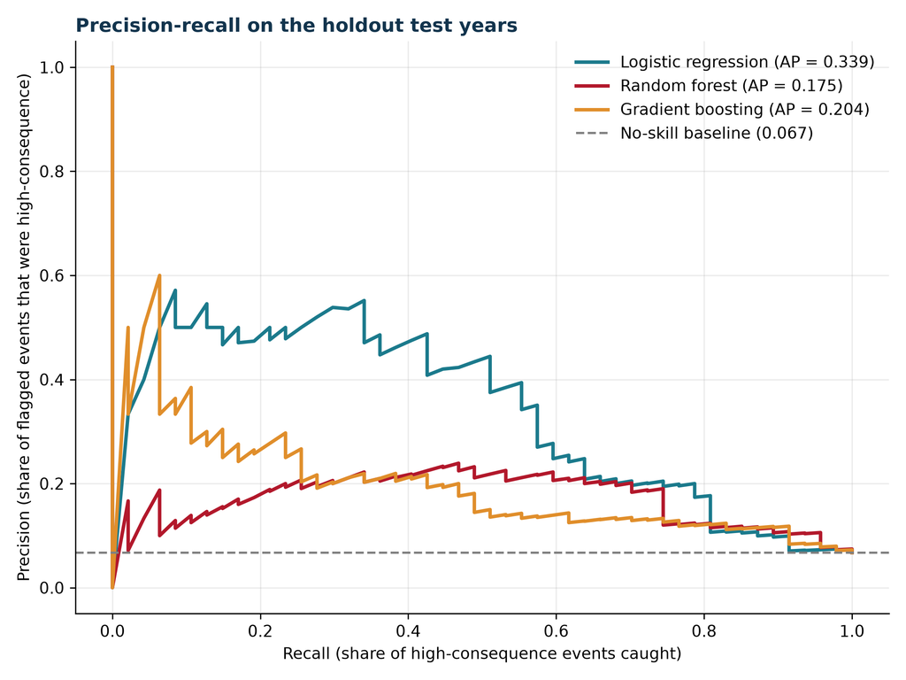

```python
ax.grid(alpha=0.25)
fig.tight_layout()
fig.savefig(f"{r.paths['figures_dir']}/19_model_pr_curve.png", dpi=int(cfg["figure_dpi"]), bbox_inches="tight")
plt.show()
```

⬇ Download figure (PNG)

## 7.5 Are the probabilities trustworthy? Calibration

| Random forest calibration | Mean predicted risk (test) | Highest predicted risk (test) |
| --- | --- | --- |
| In-bag (fit on the training predictions) | 2.5% | 48.9% |
| Out-of-fold (used here) | 4.8% | 33.8% |
| Observed test rate | 6.7% |  |

```python
from sklearn.calibration import calibration_curve

fig, axes = plt.subplots(1, 2, figsize=(11, 5), sharey=True)
panels = [(preds["Random forest"]["raw"], "Random forest: raw scores"),
          (preds["Random forest"]["cal"], "Random forest: calibrated (out-of-fold Platt)")]
for ax, (probs, title) in zip(axes, panels):
    frac_pos, mean_pred = calibration_curve(y_test, probs, n_bins=8, strategy="quantile")
    ax.plot([0, 1], [0, 1], "k--", linewidth=1, label="Perfect calibration")
    ax.plot(mean_pred, frac_pos, "o-", color="#b2182b", linewidth=2, label="Model")
    ax.set_xlim(0, max(0.3, float(np.max(probs)) * 1.1))
    ax.set_ylim(0, max(0.3, float(np.max(frac_pos)) * 1.2))
    ax.set_title(title, loc="left", fontweight="bold", color="#12344d")
    ax.set_xlabel("Mean predicted probability")
    ax.grid(alpha=0.25)
```

```python
axes[0].set_ylabel("Observed share high-consequence")
```

```python
axes[0].legend(frameon=False)
```

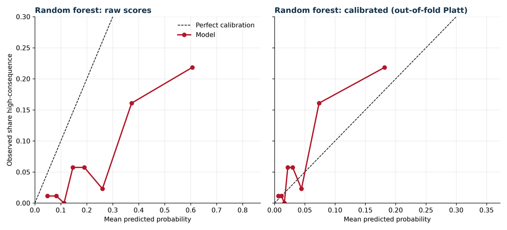

```python
fig.tight_layout()
fig.savefig(f"{r.paths['figures_dir']}/20_model_calibration.png", dpi=int(cfg["figure_dpi"]), bbox_inches="tight")
plt.show()
```

⬇ Download figure (PNG)

## 7.6 What drives the predictions

```python
import shap

explainer = shap.TreeExplainer(fitted["Random forest"])
X_shap = pd.DataFrame(X_test_i, columns=FEATURES)
sv = explainer.shap_values(X_shap)
sv = sv[1] if isinstance(sv, list) else sv
if sv.ndim == 3:
    sv = sv[:, :, 1]
shap.summary_plot(sv, X_shap, show=False, plot_size=(9, 6.5))
plt.title("Random forest: feature effects on predicted risk", loc="left",
          fontweight="bold", color="#12344d", fontsize=12)
```

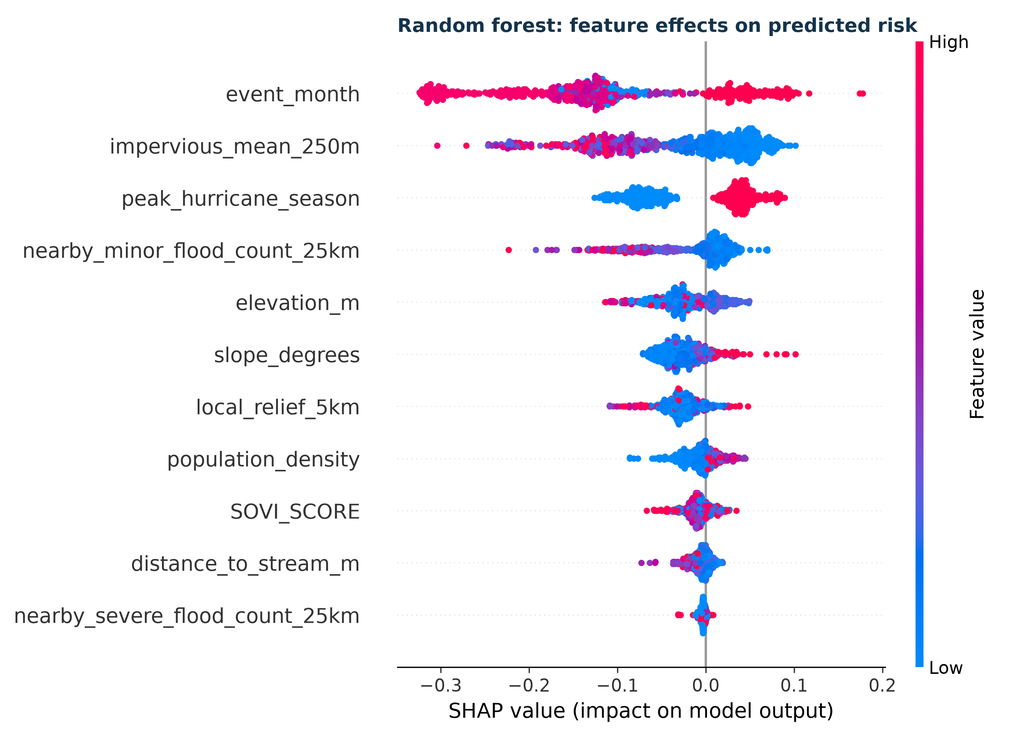

```python
plt.tight_layout()
plt.savefig(f"{r.paths['figures_dir']}/21_model_shap_summary.png", dpi=int(cfg["figure_dpi"]), bbox_inches="tight")
plt.show()
```

```python
shap_importance = (pd.Series(np.abs(sv).mean(axis=0), index=FEATURES)
                   .sort_values(ascending=False).rename("mean_abs_shap").reset_index()
                   .rename(columns={"index": "feature"}))

# Logistic-regression weights on standardized features: sign = direction of the effect
lr = fitted["Logistic regression"]
lr_coefs = pd.DataFrame({"feature": FEATURES, "standardized_coefficient": lr.coef_[0]})

# How many of the 100 trees ever split on each feature (a "dead feature" check)
tree_use = pd.DataFrame({
    "feature": FEATURES,
    "trees_using_feature": [sum(j in set(t.tree_.feature[t.tree_.feature >= 0]) for t in fitted["Random forest"].estimators_)
                            for j in range(len(FEATURES))],
})
```

⬇ Download figure (PNG)

Each dot is one test event. Dots to the right pushed that event’s predicted risk up, and color shows whether the feature’s value was high (red) or low (blue). The table combines three views of each feature: its average influence in the random forest (mean |SHAP|), the direction of its effect in the logistic regression, and how many of the forest’s 100 trees use it at all.

| feature | mean_abs_shap | standardized_coefficient | trees_using_feature | direction_in_logistic_model |
| --- | --- | --- | --- | --- |
| event_month | 0.1394 | 0.3316 | 100 | raises risk |
| impervious_mean_250m | 0.0698 | -0.7241 | 100 | lowers risk |
| peak_hurricane_season | 0.0562 | 0.5238 | 82 | raises risk |
| nearby_minor_flood_count_25km | 0.035 | -0.6477 | 99 | lowers risk |
| elevation_m | 0.0316 | -0.1525 | 98 | lowers risk |
| slope_degrees | 0.0294 | 0.2666 | 98 | raises risk |
| local_relief_5km | 0.0282 | 0.1487 | 96 | raises risk |
| population_density | 0.0144 | 0.4418 | 95 | raises risk |
| SOVI_SCORE | 0.0118 | 0.1614 | 94 | raises risk |
| distance_to_stream_m | 0.0088 | 0.0719 | 95 | raises risk |

[output cut: 1 more lines]

- **Strongest drivers** (random forest): event_month, impervious_mean_250m, peak_hurricane_season.
- **Flood history cuts both ways:** more earlier *minor* floods nearby lowers risk, while more earlier *severe* floods nearby raises risk. This is consistent with communities adapting after routine floods, while severe events cluster in the most exposed places.
- **Paved surface** lowers risk. In NOAA’s records many urban flood reports are minor nuisance flooding, while the deadliest events occur in rural, steep terrain.
- **Season** (`peak_hurricane_season`) raises risk and is used by 82 of 100 trees.

## 7.7 Lessons from development

These findings come from the team’s testing while building the models and the interactive explorer below. They are reported here as documented during development and are **not recomputed** in this document.

- **A dead feature and a mountain inversion.** An early version used an `is_tropical_event` flag that none of the 100 random-forest trees ever split on, so the whole “hurricane vs. ordinary storm” distinction rode on `event_month` alone. Across 90 mountain grid cells the team tested, 82% scored a hurricane scenario as *less* risky than a typical storm. Adding the `peak_hurricane_season` flag improved cross-validated PR-AUC (0.208 to 0.220) but did not remove the inversion (85.6% of cells), which reflects how few severe training examples exist. The logistic model cannot invert this way, because its season effect is one fixed weight applied everywhere.
- **The calibration bug.** Fitting calibration on in-bag predictions capped the most extreme input the team tried at 2.6% predicted risk; refitting on out-of-fold predictions raised it to 7.9%. The table in the calibration section shows the same effect on this run’s test years.

## 7.8 Interactive risk explorer

The team also built a browser-based explorer. It maps historical flood events, shows a structural risk surface, and has a scenario calculator where you set terrain, community, and storm inputs and see the estimated probability change.

**NoteAbout the explorer**

It runs entirely in your browser. Its models were exported from an earlier training run, so its numbers can differ slightly from the tables above. It is a teaching and exploration tool, **not an operational flood warning**.

[interactive chart not shown]

⬇ Download the explorer (HTML) to open full-screen

## 7.9 Modeling limitations

- **Small number of severe events.** About 153 high-consequence flood events in the development years; results vary noticeably across folds, and the holdout test is small.
- **Helene dominates the test years.** One storm contributes many of the test positives, so holdout scores partly measure how well the model recognizes that single event.
- **County-level vulnerability.** SOVI and population density are the same for every event in a county.
- **Static layers.** Imperviousness (2023) and the infrastructure and stream snapshots post-date most events.
- **No rainfall.** The models describe where impacts are severe *given* a flood-related event, not whether a storm will flood; they are not a forecast.

# 8 What This Means for Western North Carolina

Helene showed that in the mountains, one storm can outweigh a decade of ordinary ones. Carolina HighGround turns a decade of public records into a clearer picture of **where storms are most likely to become deadly or very costly, and why**, so that preparation can start before the next one.

## 8.1 Key findings

1. **Rare events dominate the toll.** In our 11 study counties, a single week of Helene accounts for 85% of the storm deaths and 88% of the reported damage recorded from 2016 to 2026. Planning around “typical” storms misses the ones that matter most.
2. **Place and people explain part of the risk.** Using only what surrounds an event (terrain, water, development, community vulnerability, local flood history, and season), our best model (random forest) ranks high-consequence flood events about **2.8 times better than chance** (cross-validated PR-AUC 0.221).
3. **The riskiest places are not the most developed ones.** More paved surface lowers predicted risk, while steeper slopes raise it: severe harm concentrates in rural, mountainous terrain rather than in cities.
4. **Vulnerability and history matter.** Higher county social vulnerability raises risk. Earlier *minor* floods nearby lower it, while earlier *severe* floods raise it.

## 8.2 Who could use this

| Audience | How it helps |
| --- | --- |
| **County emergency managers** | Identify communities whose surroundings resemble past high-consequence events, and pre-position supplies (water, generators) before hurricane season |
| **NCDOT and local road agencies** | Prioritize inspection of crossings in steep, stream-dense, rural areas, where blocked roads cut off communities for weeks |
| **Schools and community organizations** | Plan continuity for places likely to lose power, water, and internet access for long periods, as our interviewees experienced |
| **Residents** | Understand that “hurricanes don’t reach the mountains” is no longer a safe assumption |

## 8.3 Next steps

- **Add rainfall** (e.g., Stage IV radar totals) so the model can separate *how much rain fell* from *where it fell*.
- **Use tract-level vulnerability** (CDC/ATSDR SVI) instead of county averages, to see *who* within a county is most exposed.
- **Measure upstream drainage** (flow accumulation, HAND) rather than point-and-buffer proximity.
- **Validate with local partners** in Buncombe and neighboring counties, and turn the interactive explorer into a planning tool.

**Carolina HighGround** · Carolina Data Challenge 2026 · Kent Lee, Matthew Martin, Aaron Chen, Minh Nguyen. Built with public data from NOAA, USGS, NCDOT, USDA, FEMA, and the U.S. Census Bureau. Not an operational flood warning.

# 9 Appendix

## 9.1 Downloads

⬇ carolina_highground_tables.zip

- **Machine-learning files** (Parquet tables + documentation, also in `data/ml_ready`)

⬇ carolina_highground_ml_ready.zip

## 9.2 Limitations

- **Point and buffer features only.** No upstream contributing area, HAND, or flow accumulation is computed, and HUC12 membership is not a drainage-area measure.
- **Coordinates.** 4,279 events (mostly forecast-zone records) have no usable NOAA coordinates. Their spatial features are missing; no centroids are substituted.
- **Timing.** Imperviousness is a 2023 layer, and NCDOT and NHD are current snapshots, not conditions in the year of each event.
- **Damage** figures are NOAA estimates in nominal dollars. Blank damage fields are treated as 0 and flagged.
- **Soils** are summarized from tabular SSURGO only. **Rainfall** is not included. **Community vulnerability** enters only at the modeling stage, as county-level FEMA NRI values.
- **Partial year** 2026 is incomplete.

## 9.3 Configuration

| Setting | Value |
| --- | --- |
| years | 2016-2026 (partial: 2026) |
| study area | Western North Carolina: Buncombe, Henderson, Haywood, Madison, McDowell, Transylvania, Yancey, Avery, Watauga, Jackson, Swain |
| CRS (analysis / geographic) | EPSG:32119 / EPSG:4326 |
| buffers (event / stream / infrastructure) | 250 / 250 / 1000 m |
| feature event scope | all |
| NHD flowline FTypes | 460, 558 |
| target | deaths >= 1 OR damage > q0.9 of positive damage (basis: train_split) |
| split | train <= 2021, validation <= 2023, test after |
| download_data / use_cached_features / refresh_derived_data | FALSE / TRUE / FALSE |

## 9.4 Input inventory

| dataset | path | required | status | size_mb | modified | used_for |
| --- | --- | --- | --- | --- | --- | --- |
| NOAA Storm Events | data/raw/noaa | True | found | 126.3 | 2026-09-26 | events, outcomes, targets |
| NHD HR state ZIP | data/raw/nhd/NHD_H_North_Carolina_State_Shape.zip | False | found | 834.3 | 2026-09-26 | streams (extracted only if needed) |
| NHD extracted shapefiles | data/raw/nhd/extracted | False | found | 2541.1 | 2026-09-26 | streams, HUC12 |
| NCDOT culverts | data/raw/ncdot/ncdot_culverts_nc.gpkg | False | found | 1.5 | 2026-09-26 | culvert features |
| NCDOT structures | data/raw/ncdot/ncdot_structures_nc.gpkg | False | found | 7.1 | 2026-09-26 | structure features |
| DEM | data/raw/dem_3dep/3dep_dem_north_carolina_epsg32119.tif | False | found | 114.2 | 2026-09-26 | elevation |
| Slope | data/raw/dem_3dep/slope_degrees_epsg32119.tif | False | found | 135.7 | 2026-09-26 | slope |
| Roughness | data/raw/dem_3dep/roughness_epsg32119.tif | False | found | 113 | 2026-09-26 | roughness |
| NLCD imperviousness | data/raw/nlcd/annual_nlcd_fractional_impervious_2023_NC.tif | False | found | 22.3 | 2026-09-26 | imperviousness |
| SSURGO tables | data/raw/usda_soils | False | found | 12.4 | 2026-09-26 | soil summary |

[output cut: 7 more lines]

## 9.5 Pipeline log

Every warning, skipped step, and fallback recorded during this render:

| level | input | message | affects |
| --- | --- | --- | --- |
| info | spatial feature cache | Reusing cached features from data/derived/event_spatial_features.parquet |  |

## 9.6 Session info

```
R version 4.5.3 (2026-03-11)
```

```
Packages: reticulate 1.47.0, htmltools 0.5.9, base64enc 0.1-6, digest 0.6.39, fs 2.1.0, jsonlite 2.0.0, DT 0.34.0, patchwork 1.3.2, scales 1.4.0, janitor 2.2.1, arrow 25.0.1, terra 1.9-50, sf 1.1-3, lubridate 1.9.5, forcats 1.0.1, stringr 1.6.0, dplyr 1.2.1, purrr 1.2.2, readr 2.2.0, tidyr 1.3.2, ti…
```